# Case Study II

Emily Schmidt and Genta Mehmeti

2023-04-06

# 1 Understanding Quality Perceptions of Smartphones

The product management team intends to develop a deeper understanding of customers’ product quality perceptions regarding its constituent dimensions. The project team pursues the user-based perspective on product quality and accordingly characterizes perceived product quality as the customer’s judgment of the overall excellence, esteem, or superiority of a product (with respect to its intended purposes) relative to the alternative products. Researchers recognize that perceived product quality needs to be conceptualized as a multidimensional construct. Therefore, the team hopes to establish relevant quality dimensions that significantly define key outcome variables such as willingness to pay premium (WTPP) and repurchase intentions (RI). The operations management department hopes that this project will provide them with a criterion variable to assess the success or failure of their quality improvement initiatives.  
- *Resource*: Case Study II

## 1.1 Libraries

```r
library(rcompanion)   # Histogram and Normal Curve
library(nortest)      # Kolmogorov-Smirnov-Test
library(corrplot)     # Correlation matrix plot
library(olsrr)        # VIF and Tolerance Values
library(dplyr)
library(pastecs)
library(REdaS)        # Bartelett's Test
library(psych)
library(reshape)      # Melt
library(ggplot2)
library(naniar)       # Missing values analysis
library(tidyr)        # Help replace missing values with mean
library(kableExtra)   # Tables
library(ggplot2)      # Plots
library(GPArotation)
library(dplyr)
library(gridExtra)
library(data.table)
```

```r
# Clear the enviroment and console
rm(list=ls())
graphics.off()
#shell("cls")
```

```r
# Read the data file
phone = read.csv("Data File_Case_Study_Factor Analysis_MD.csv",header = TRUE)
```

## 1.2 Exploratory Analysis

```r
# Keep only qd1 to qd33 for Problem 1
phone_133 <- phone[c(9:41)]

# Return the column names containing missing observations
list_na = colnames(phone_133)[apply(phone_133,2,anyNA)]
list_na # 6 variables missing data
```

```
## [1] "qd22" "qd26" "qd28" "qd29" "qd31" "qd33"
```

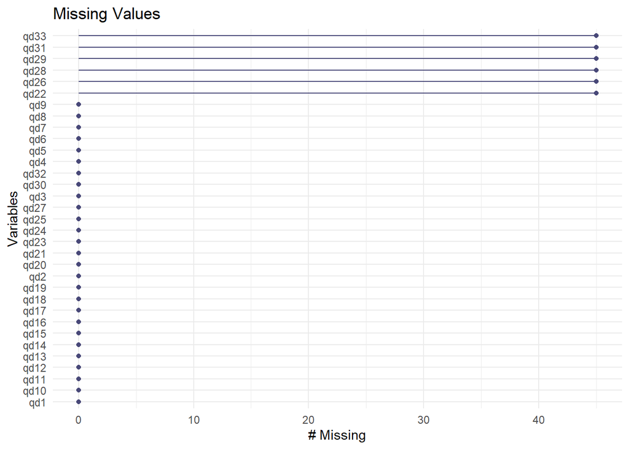

```r
# Visualize missing values
gg_miss_var(phone_133) + ggtitle("Missing Values")
```

```r
# Total missing values - Calculation
sum_missing_133 = sum(is.na(phone_133)) # 270 NAs
x = 33*1014
total_missing_133 = sum_missing_133/x # 0.8% of the data is missing

# Remove rows with missing data
phone_133_all <- na.omit(phone_133) # 969 observations, 4.43% of data is missing

# Replace mean values for all values missing
phone_133_mean <- phone_133 |>
  mutate(across(everything(), ~ ifelse(is.na(.), mean(., na.rm = TRUE), .)))
```

```r
# Keep only qd1 to qd33, wtp1, wpt2, wtp3, ri1, adn ri2 for Problem 2
phone_all <- phone[c(9:41,43:45,51:52)]

# Return the column names containing missing observations
list_na = colnames(phone_all)[apply(phone_all,2,anyNA)]
list_na # 6 variables missing data
```

```
## [1] "qd22" "qd26" "qd28" "qd29" "qd31" "qd33"
```

```r
# Remove rows with missing data
phone_all <- na.omit(phone_all) # 969 observations
```

For *Problem 1*, certain quality variables were kept within the dataset for factor analysis per the case study’s directions. Out of the 33 variables, six have missing values ($qd22$, $qd26$, $qd28$, $qd29$, $qd31$, and $qd33$). There are 270 NAs which accounts for 4.43% of the 1,014 smartphone customers. Therefore, the analysis will continue only using 969 observations.

```r
dim(phone_133_all) # Get or set the dimension of the specified matrix, array or data frame, 969 rows and 33 variables
```

```
## [1] 969  33
```

```r
str(phone_133_all) # Compactly displaying the internal structure of a R object
```

```
## 'data.frame':    969 obs. of  33 variables:
##  $ qd1 : int  3 4 3 5 4 3 4 3 4 4 ...
##  $ qd2 : int  4 4 4 5 4 4 5 3 4 5 ...
##  $ qd3 : int  3 3 3 4 5 3 5 4 5 3 ...
##  $ qd4 : int  3 6 2 3 2 5 2 2 2 5 ...
##  $ qd5 : int  4 4 3 5 3 3 5 3 4 4 ...
##  $ qd6 : int  3 4 3 5 3 3 3 3 3 3 ...
##  $ qd7 : int  4 4 3 5 4 4 5 3 4 5 ...
##  $ qd8 : int  3 4 4 5 4 3 3 4 4 3 ...
##  $ qd9 : int  3 4 3 4 3 3 4 4 3 5 ...
##  $ qd10: int  3 4 3 5 4 3 5 4 3 4 ...
##  $ qd11: int  3 3 4 5 5 3 4 3 5 3 ...
##  $ qd12: int  3 4 5 5 4 4 5 4 4 5 ...
##  $ qd13: int  4 4 3 5 4 3 4 4 5 3 ...
##  $ qd14: int  3 4 3 4 3 3 4 4 3 5 ...
```

[output cut: 21 more lines]

```r
# Produce result summaries
summary <- data.frame(mean = sapply(phone_133_all[,c(1:33)], mean,na.rm = T)
                  ,median = sapply(phone_133_all[,c(1:33)], median,na.rm = T)
                  ,min = sapply(phone_133_all[,c(1:33)], min,na.rm = T)
                  ,max = sapply(phone_133_all[,c(1:33)], max,na.rm = T)
                  ,sd = sapply(phone_133_all[,c(1:33)], sd,na.rm = T))
colnames(summary) = c("Mean","Median","Min","Max","Standard Deviation")
kable(summary) |>  kable_classic() |>
    kableExtra::kable_styling(bootstrap_options = c("striped", "hover", "condensed","responsive")) |>
    kable_styling(position = "center") # Use kable to design table
```

|  | Mean | Median | Min | Max | Standard Deviation |
| --- | --- | --- | --- | --- | --- |
| qd1 | 4.054696 | 4 | 1 | 5 | 0.8106351 |
| qd2 | 4.183694 | 4 | 1 | 5 | 0.7907670 |
| qd3 | 3.938080 | 4 | 1 | 5 | 0.8697658 |
| qd4 | 3.703818 | 4 | 1 | 7 | 1.4979310 |
| qd5 | 3.917441 | 4 | 1 | 5 | 0.9788018 |
| qd6 | 3.746130 | 4 | 1 | 5 | 0.8916208 |
| qd7 | 4.205366 | 4 | 1 | 5 | 0.7442147 |
| qd8 | 3.948400 | 4 | 1 | 5 | 0.8427008 |
| qd9 | 3.914345 | 4 | 1 | 5 | 0.8466576 |
| qd10 | 4.054696 | 4 | 1 | 5 | 0.7990834 |
| qd11 | 3.887513 | 4 | 1 | 5 | 0.8888304 |
| qd12 | 4.254902 | 4 | 1 | 5 | 0.7551744 |
| qd13 | 4.153767 | 4 | 2 | 5 | 0.7754556 |
| qd14 | 3.840041 | 4 | 1 | 5 | 0.8601643 |
| qd15 | 3.933953 | 4 | 1 | 5 | 0.8453647 |
| qd16 | 3.993808 | 4 | 1 | 5 | 0.8660032 |
| qd17 | 3.849329 | 4 | 1 | 5 | 0.8418312 |
| qd18 | 3.440660 | 3 | 1 | 5 | 0.8545201 |
| qd19 | 3.930857 | 4 | 1 | 5 | 0.8296964 |
| qd20 | 4.126935 | 4 | 1 | 5 | 0.7803018 |
| qd21 | 3.837977 | 4 | 1 | 5 | 0.8834816 |
| qd22 | 3.974200 | 4 | 1 | 5 | 0.9228252 |
| qd23 | 3.685243 | 4 | 1 | 7 | 1.5531223 |
| qd24 | 3.864809 | 4 | 1 | 5 | 0.8462911 |
| qd25 | 3.744066 | 4 | 1 | 5 | 0.8933457 |
| qd26 | 3.795666 | 4 | 1 | 5 | 0.9019846 |
| qd27 | 4.149639 | 4 | 1 | 5 | 0.7868380 |
| qd28 | 3.629515 | 4 | 1 | 5 | 0.8825652 |
| qd29 | 3.957688 | 4 | 1 | 5 | 0.9388676 |
| qd30 | 4.163055 | 4 | 1 | 5 | 0.7688656 |
| qd31 | 3.758514 | 4 | 1 | 5 | 0.8241526 |
| qd32 | 3.951496 | 4 | 1 | 5 | 0.8020637 |
| qd33 | 3.924665 | 4 | 1 | 5 | 0.9356907 |

All variables are integers and have a range of different values for the mean, median, minimum, maximum, and standard deviation. It is noticed that two of the 33 questions have a maximum of seven which indicates that those use another measurement scale. Additionally, for question $qd13$, the minimum value is 2 while all other predictors have a 1. The majority of these survey questions have a median higher than 3, but $qd18$ is the only one that has a 3 as its middle number.

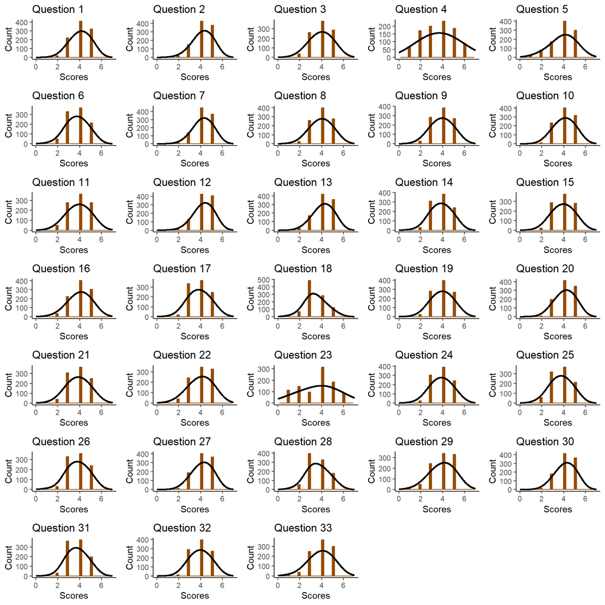

```r
# Create a list of plots
plots <- lapply(1:33, function(i) {
  # Store data in column.i as x
  x <- phone_133_all[,i]

  ggplot(data.frame(x), aes(x)) +
    geom_histogram( fill = "#964B00", color = "#964B00", bandwidth = 2) +
    geom_density(aes(y = 0.85*..count..), color = "black", adjust = 4, size = 1) +
    ggtitle(paste("Question", i)) +
    xlab("Scores") +
    ylab("Count") +
    xlim(0, 7) +
    theme_classic()
})

# Display the plots with 9 columns
gridExtra::grid.arrange(grobs = plots, ncol = 5)
```

```r
stat.desc(phone_133_all, norm = TRUE)
```

```
##                        qd1           qd2           qd3           qd4
## nbr.val       9.690000e+02  9.690000e+02  9.690000e+02  9.690000e+02
## nbr.null      0.000000e+00  0.000000e+00  0.000000e+00  0.000000e+00
## nbr.na        0.000000e+00  0.000000e+00  0.000000e+00  0.000000e+00
## min           1.000000e+00  1.000000e+00  1.000000e+00  1.000000e+00
## max           5.000000e+00  5.000000e+00  5.000000e+00  7.000000e+00
## range         4.000000e+00  4.000000e+00  4.000000e+00  6.000000e+00
## sum           3.929000e+03  4.054000e+03  3.816000e+03  3.589000e+03
## median        4.000000e+00  4.000000e+00  4.000000e+00  4.000000e+00
## mean          4.054696e+00  4.183695e+00  3.938080e+00  3.703818e+00
## SE.mean       2.604135e-02  2.540309e-02  2.794090e-02  4.812048e-02
## CI.mean.0.95  5.110401e-02  4.985148e-02  5.483172e-02  9.443248e-02
## var           6.571293e-01  6.253124e-01  7.564926e-01  2.243797e+00
## std.dev       8.106351e-01  7.907670e-01  8.697658e-01  1.497931e+00
## coef.var      1.999250e-01  1.890116e-01  2.208603e-01  4.044289e-01
## skewness     -4.485546e-01 -7.880215e-01 -3.885693e-01  9.398390e-02
## skew.2SE     -2.854581e+00 -5.014933e+00 -2.472837e+00  5.981092e-01
## kurtosis     -3.466947e-01  4.832489e-01 -4.721767e-01 -6.991196e-01
## kurt.2SE     -1.104304e+00  1.539261e+00 -1.503994e+00 -2.226860e+00
## normtest.W    8.357031e-01  8.104080e-01  8.553564e-01  9.487279e-01
## normtest.p    1.936299e-30  3.105757e-32  6.891791e-29  7.540402e-18
##                        qd5           qd6           qd7           qd8
## nbr.val       9.690000e+02  9.690000e+02  9.690000e+02  9.690000e+02
## nbr.null      0.000000e+00  0.000000e+00  0.000000e+00  0.000000e+00
## nbr.na        0.000000e+00  0.000000e+00  0.000000e+00  0.000000e+00
## min           1.000000e+00  1.000000e+00  1.000000e+00  1.000000e+00
## max           5.000000e+00  5.000000e+00  5.000000e+00  5.000000e+00
## range         4.000000e+00  4.000000e+00  4.000000e+00  4.000000e+00
## sum           3.796000e+03  3.630000e+03  4.075000e+03  3.826000e+03
## median        4.000000e+00  4.000000e+00  4.000000e+00  4.000000e+00
## mean          3.917441e+00  3.746130e+00  4.205366e+00  3.948400e+00
## SE.mean       3.144364e-02  2.864299e-02  2.390762e-02  2.707145e-02
## CI.mean.0.95  6.170556e-02  5.620950e-02  4.691674e-02  5.312549e-02
## var           9.580529e-01  7.949876e-01  5.538555e-01  7.101446e-01
## std.dev       9.788018e-01  8.916208e-01  7.442147e-01  8.427008e-01
## coef.var      2.498575e-01  2.380112e-01  1.769679e-01  2.134284e-01
## skewness     -7.788925e-01 -2.854318e-01 -6.952848e-01 -3.887909e-01
## skew.2SE     -4.956836e+00 -1.816475e+00 -4.424760e+00 -2.474247e+00
## kurtosis      1.057604e-01 -2.252289e-01  4.171334e-01 -3.060088e-01
## kurt.2SE      3.368719e-01 -7.174071e-01  1.328668e+00 -9.747100e-01
```

[output cut: 134 more lines]

```
## range         4.000000e+00
## sum           3.803000e+03
## median        4.000000e+00
## mean          3.924665e+00
## SE.mean       3.005872e-02
## CI.mean.0.95  5.898776e-02
## var           8.755171e-01
## std.dev       9.356907e-01
## coef.var      2.384129e-01
## skewness     -6.513403e-01
## skew.2SE     -4.145100e+00
## kurtosis      1.615565e-01
## kurt.2SE      5.145953e-01
## normtest.W    8.535461e-01
## normtest.p    4.883802e-29
```

The histograms help the reader better understand the distribution of the each survey question. There are several observations that help depict how customers responded:

1. A majority of the questions have a greater count (200+) of responses from 3 to 5 (or 7).
2. $qd4$ and $qd23$ have a slightly different distribution as there are more responses within the 1 and 2 range. This is because the range is 1 to 7 instead of all others that follow a 5-point scale.
3. Typically, customers will choose 4 as their answer to a survey question.

Since there are assumptions of normality that need to be fulfilled later, it is critical to understand the skewness and kurtosis of each column. To be normal, a dataset needs to be symmetric and have a bell-shaped curve.

```r
lillie.test(phone_133_all$qd5)
```

```
##
##  Lilliefors (Kolmogorov-Smirnov) normality test
##
## data:  phone_133_all$qd5
## D = 0.256, p-value < 2.2e-16
```

```r
lillie.test(phone_133_all$qd16)
```

```
##
##  Lilliefors (Kolmogorov-Smirnov) normality test
##
## data:  phone_133_all$qd16
## D = 0.23144, p-value < 2.2e-16
```

```r
lillie.test(phone_133_all$qd18)
```

```
##
##  Lilliefors (Kolmogorov-Smirnov) normality test
##
## data:  phone_133_all$qd18
## D = 0.28107, p-value < 2.2e-16
```

```r
lillie.test(phone_133_all$qd22)
```

```
##
##  Lilliefors (Kolmogorov-Smirnov) normality test
##
## data:  phone_133_all$qd22
## D = 0.20878, p-value < 2.2e-16
```

```r
lillie.test(phone_133_all$qd33)
```

```
##
##  Lilliefors (Kolmogorov-Smirnov) normality test
##
## data:  phone_133_all$qd33
## D = 0.22042, p-value < 2.2e-16
```

In regard to kurtosis, there are five questions that have an absolute value of 1.2. They are further investigated to determine if a sample comes from a normal distribution. The Kolmogorov-Smirnov rejects the normality assumption for those five predictors. These variables will be on the watch list moving forward.

# 2 Problem 1: Orthogonal Factor Analysis

Run a factor analysis with the quality items $qd_1$ to $qd_33$. In this first step run a principal axis factoring and use varimax rotation. Go through the steps of a factor analysis that you have learned i.e. start with looking at the correlation matrix, check whether the data set and all of its variables are suitable for factor analysis etc. Make appropriate decisions and decide on a final factor solution. Interpret the factors based on the literature review on quality dimensions (see table 1). Develop a report i.e. in html of your key results and justify the choices you made in the course of the analysis. Do all of the variables in your final solution show clear loading patterns? For your final solution run a principal component analysis and compare the results. Are there differences to your solution based on principal axis factoring? What do the eigenvalues of the factors/quality dimensions tell us about their relevance for repurchase behavior? Please explain!

## 2.1 Correlation Matrix

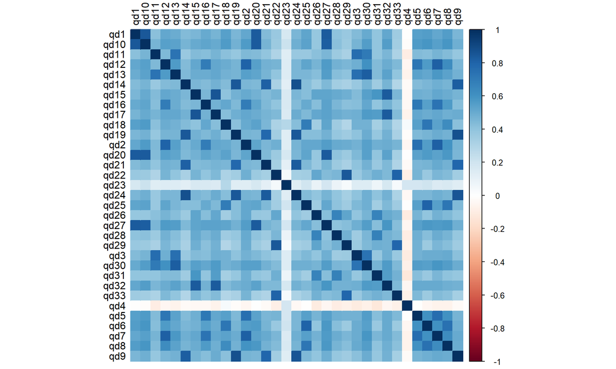

```r
corr_phone_133 <- cor(phone_133_all)
corrplot(corr_phone_133, tl.col = "black", number.cex = 0.8, method = 'color', order = 'alphabet')
```

A primary goal in factor analysis is to ensure that the variables are suitable to obtain distinct dimensions in order to reduce the number of items to explain and to interpret the results. The correlation matrix shows that some variables are highly correlated with one another while others have almost no relationship. Here are several examples:

- $qd9$ and $qd19$ have the highest correlation at 88%
- There are an additional 20+ relationships that have a correlation between 80% and 87%, indicated by the larger and darker blue squares
- Relationships that are practically non-existent derive from $qd4$ and $q23$. Later in oblique factor analysis, this may be problematic due to almost non-correlation.

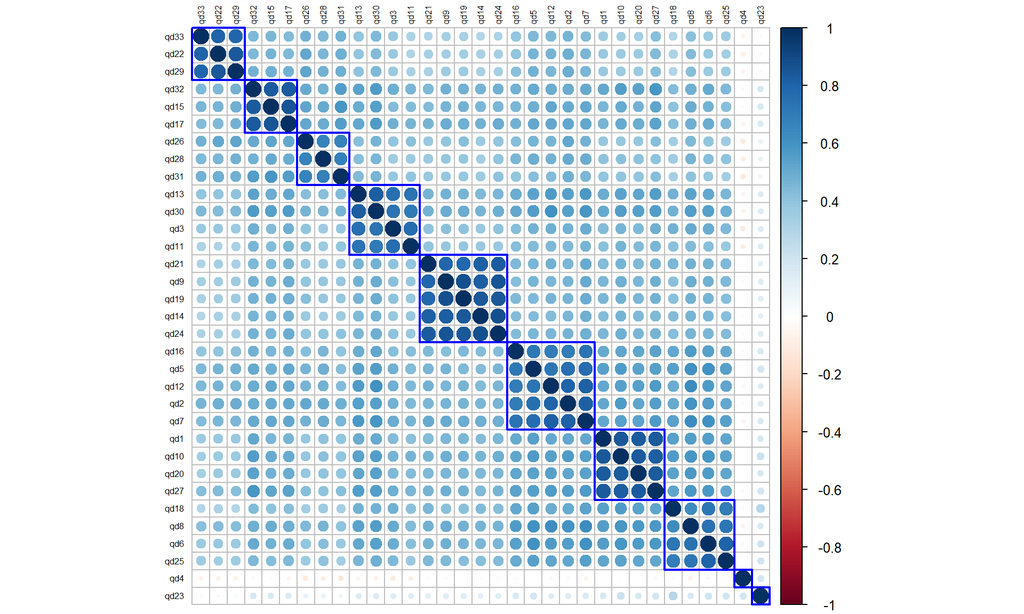

```r
corrplot(corr_phone_133, tl.col = "black", number.cex = 0.8, order = "hclust", tl.cex = 0.5, addrect = 10, rect.col = 'blue')
```

```r
# Resource [4, see end of htlm]
```

One of the requirements needed for factor analysis is that some correlations in the matrix should exceed 30%. This criterion has been met. Having high and low correlations between the predictors means that different dimensions can be determined through the creation of several factors. Before moving forward, we can already depict ten factors based on their correlations through the blue squares on the correlation matrix. To see if this is concrete evidence of keeping all these potential dimensions, additional work is needed.

## 2.2 Bartlett’s Test, KMO, & Anti-Image Correlation

```r
bart_spher(phone_133_all)
```

```
##  Bartlett's Test of Sphericity
##
## Call: bart_spher(x = phone_133_all)
##
##      X2 = 30857.911
##      df = 528
## p-value < 2.22e-16
```

The Bartlett-Test (test of sphericity) ‘tests the hypothesis that the sample originates from a population, where are variables are uncorrelated’. The main assumption is that the variables in a population are normally distributed. Since this is not the case for five predictors, this test may be invalid. Instead, other tests like the Kaiser-Meyer-Olkin (KMO) or Measure of Sampling Adequacy (MSA) can be utilized and are more appropriate.

```r
KMOTEST <- KMOS(phone_133_all)
KMOTEST
```

```
##
## Kaiser-Meyer-Olkin Statistics
##
## Call: KMOS(x = phone_133_all)
##
## Measures of Sampling Adequacy (MSA):
##       qd1       qd2       qd3       qd4       qd5       qd6       qd7       qd8
## 0.9611377 0.9665563 0.9570940 0.6422860 0.9794715 0.9562057 0.9700763 0.9809143
##       qd9      qd10      qd11      qd12      qd13      qd14      qd15      qd16
## 0.9614243 0.9700651 0.9553342 0.9692788 0.9604076 0.9606687 0.9463654 0.9818514
##      qd17      qd18      qd19      qd20      qd21      qd22      qd23      qd24
## 0.9526272 0.9694107 0.9596475 0.9660218 0.9745578 0.9273572 0.9025359 0.9572029
##      qd25      qd26      qd27      qd28      qd29      qd30      qd31      qd32
## 0.9554307 0.9658695 0.9662994 0.9620148 0.9348269 0.9651743 0.9595275 0.9632269
##      qd33
## 0.9502085
##
## KMO-Criterion: 0.961722
```

The KMO test measures sampling adequacy (MSA) by taking the ‘ratio of the sum of squared correlations to the sum of squared correlations plus the sum of squared partial correlations’. If the value is greater than 0.6, the data can be reduced to less dimensions. For this factor analysis, it surpasses that requirement at 0.96, which means that the data is a good fit for FA since it has a value close to 1.

```r
sort(KMOTEST$MSA)
```

```
##       qd4      qd23      qd22      qd29      qd15      qd33      qd17      qd11
## 0.6422860 0.9025359 0.9273572 0.9348269 0.9463654 0.9502085 0.9526272 0.9553342
##      qd25       qd6       qd3      qd24      qd31      qd19      qd13      qd14
## 0.9554307 0.9562057 0.9570940 0.9572029 0.9595275 0.9596475 0.9604076 0.9606687
##       qd1       qd9      qd28      qd32      qd30      qd26      qd20      qd27
## 0.9611377 0.9614243 0.9620148 0.9632269 0.9651743 0.9658695 0.9660218 0.9662994
##       qd2      qd12      qd18      qd10       qd7      qd21       qd5       qd8
## 0.9665563 0.9692788 0.9694107 0.9700651 0.9700763 0.9745578 0.9794715 0.9809143
##      qd16
## 0.9818514
```

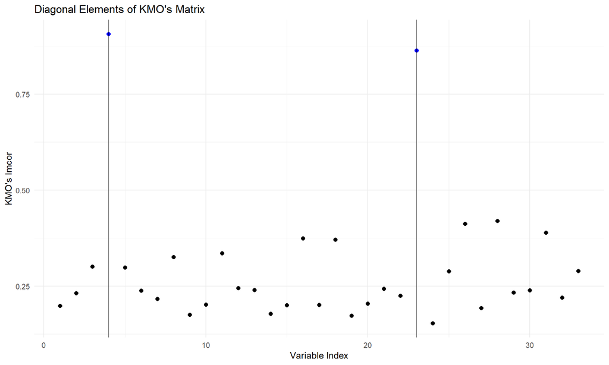

```r
# Compute the Kaiser-Meyer-Olkin (KMO) measure for a dataset with 133 variables
kmo_results <- KMO(phone_133_all)

# Create a data frame with the diagonal values and their indices
df <- data.frame(values = diag(kmo_results$ImCov), index = 1:length(diag(kmo_results$ImCov)))

# Plot the diagonal values using ggplot2
ggplot(df, aes(x = index, y = values)) +
  geom_point(size = 2, color = ifelse(df$values > 0.8, "blue", "black")) +
  geom_vline(xintercept = 4,lwd = .05,color = "black") +
  geom_vline(xintercept = 23,lwd = .05,color = "black") +
  scale_x_continuous(name = "Variable Index") +
  scale_y_continuous(name = "KMO's Imcor") +
  ggtitle("Diagonal Elements of KMO's Matrix") +
  theme_minimal()
```

The Anti-Image Correlation ‘measures the sampling adequacy for each individual variable’. From using this type of matrix, ‘items that do not correlate with any of the factors can be easily identified. If a value is below 0.5, the corresponding variable should be removed from the analysis’. As seen above, all elements are above that threshold. But, $qd4$ stands apart because it is much lower at 0.64 and the next lowest value ($qd23$) is at 0.90. $qd4$ will be on the watch list as the analysis continues.

Additionally, it is interesting to look at the MSA diagonals because it relates to how well those factors/dimensions have been covered throughout the survey questions. In the instance of $qd4$ and $qd23$, they both are quite high compared to every other question according to the blue dots. Therefore, we add $qd23$ to the watch list.

## 2.3 Principal Axis Factoring

Principal axis factoring (PAF) is an exploratory factor method that is used to help represent a multitude of relationships among normally distributed or scale variables in a parsimonious manner. First, we explore PAF because we want to review the correlation matrix in a modified way. This means that the correlations of each item with itself are replaced with a “communality”— a measure of that item’s relation to all other items. This means that this type of analysis is directed at understanding only the covariation among the variables.

To obtain the best model, we will test several scenarios with different factors to see which ones have the lowest $BIC$ and $rms$, but the highest $fit$. Earlier in the correlation matrix, there were ten groupings of questions and five of those will be tested to get the best results to find the final solution.

**Note**: Anything lower than 5-factor or more than 10-factor will not be shown due to poor results.

```r
FA6 <- fa(phone_133_all, nfactors = 6, rotate = "varimax", fm = "pa") # Principal factor solution (pa)
summary(FA6)
```

```
##
## Factor analysis with Call: fa(r = phone_133_all, nfactors = 6, rotate = "varimax", fm = "pa")
##
## Test of the hypothesis that 6 factors are sufficient.
## The degrees of freedom for the model is 345  and the objective function was  2.65
## The number of observations was  969  with Chi Square =  2523.57  with prob <  0
##
## The root mean square of the residuals (RMSA) is  0.03
## The df corrected root mean square of the residuals is  0.04
##
## Tucker Lewis Index of factoring reliability =  0.89
## RMSEA index =  0.081  and the 10 % confidence intervals are  0.078 0.084
## BIC =  151.26
```

```r
FA7 <- fa(phone_133_all, nfactors = 7, rotate = "varimax", fm = "pa")
summary(FA7)
```

```
##
## Factor analysis with Call: fa(r = phone_133_all, nfactors = 7, rotate = "varimax", fm = "pa")
##
## Test of the hypothesis that 7 factors are sufficient.
## The degrees of freedom for the model is 318  and the objective function was  1.36
## The number of observations was  969  with Chi Square =  1293.21  with prob <  1.3e-117
##
## The root mean square of the residuals (RMSA) is  0.02
## The df corrected root mean square of the residuals is  0.03
##
## Tucker Lewis Index of factoring reliability =  0.946
## RMSEA index =  0.056  and the 10 % confidence intervals are  0.053 0.06
## BIC =  -893.44
```

```r
FA8 <- fa(phone_133_all, nfactors = 8, rotate = "varimax", fm = "pa")
summary(FA8)
```

```
##
## Factor analysis with Call: fa(r = phone_133_all, nfactors = 8, rotate = "varimax", fm = "pa")
##
## Test of the hypothesis that 8 factors are sufficient.
## The degrees of freedom for the model is 292  and the objective function was  0.7
## The number of observations was  969  with Chi Square =  670  with prob <  9.6e-32
##
## The root mean square of the residuals (RMSA) is  0.01
## The df corrected root mean square of the residuals is  0.02
##
## Tucker Lewis Index of factoring reliability =  0.977
## RMSEA index =  0.037  and the 10 % confidence intervals are  0.033 0.04
## BIC =  -1337.87
```

```r
FA9 <- fa(phone_133_all, nfactors = 9, rotate = "varimax", fm = "pa")
summary(FA9)
```

```
##
## Factor analysis with Call: fa(r = phone_133_all, nfactors = 9, rotate = "varimax", fm = "pa")
##
## Test of the hypothesis that 9 factors are sufficient.
## The degrees of freedom for the model is 267  and the objective function was  0.61
## The number of observations was  969  with Chi Square =  575.91  with prob <  9.1e-25
##
## The root mean square of the residuals (RMSA) is  0.01
## The df corrected root mean square of the residuals is  0.01
##
## Tucker Lewis Index of factoring reliability =  0.98
## RMSEA index =  0.035  and the 10 % confidence intervals are  0.031 0.038
## BIC =  -1260.05
```

```r
FA10 <- fa(phone_133_all, nfactors = 10, rotate = "varimax", fm = "pa")
summary(FA10)
```

```
##
## Factor analysis with Call: fa(r = phone_133_all, nfactors = 10, rotate = "varimax", fm = "pa")
##
## Test of the hypothesis that 10 factors are sufficient.
## The degrees of freedom for the model is 243  and the objective function was  0.48
## The number of observations was  969  with Chi Square =  451.23  with prob <  1.1e-14
##
## The root mean square of the residuals (RMSA) is  0.01
## The df corrected root mean square of the residuals is  0.01
##
## Tucker Lewis Index of factoring reliability =  0.985
## RMSEA index =  0.03  and the 10 % confidence intervals are  0.025 0.034
## BIC =  -1219.7
```

```r
# Create a data frame with three columns
my_table <- data.frame(
  Model = c("6-factor", "7-factor", "8-factor", "9-factor", "10-factor"),
  BIC = c(151.3, -893.4, -1338.0, -1260.0, -1220.0),
  rms = c(0.03059, 0.0209, 0.01212 , 0.007739, 0.006385),
  fit = c(0.9804, 0.9843, 0.9873, 0.9898, 0.9904))

# Print the table
print(my_table)
```

```
##       Model     BIC      rms    fit
## 1  6-factor   151.3 0.030590 0.9804
## 2  7-factor  -893.4 0.020900 0.9843
## 3  8-factor -1338.0 0.012120 0.9873
## 4  9-factor -1260.0 0.007739 0.9898
## 5 10-factor -1220.0 0.006385 0.9904
```

There are other factors such as $crms$, $objective$, and $TLI$ that are shown in the summaries, but they are not the main priorities when choosing the best model. From the five methods, it appears that 8-factor and 9-factor models are relatively close in comparison. Therefore, the next step will to analyze which one does a better job when potentially eliminating certain questions from the watch list.

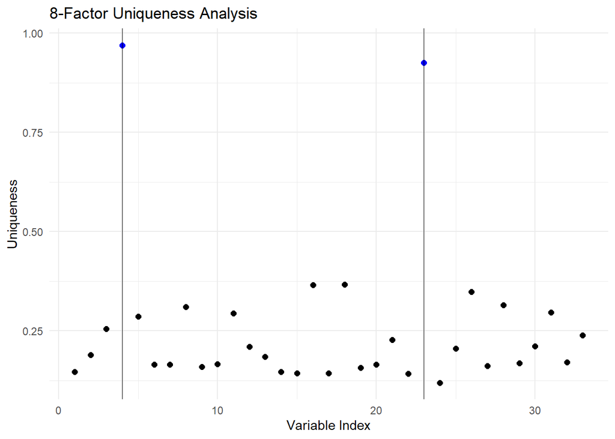

```r
FA8_Unq <- factanal(phone_133_all, factors = 8, rotation = 'varimax')

# Create a data frame with the diagonal values and their indices
df <- data.frame(values = FA8_Unq$uniquenesses, index = 1:33)

# Plot the diagonal values using ggplot2
ggplot(df, aes(x = index, y = values)) +
  geom_point(size = 2, color = ifelse(df$values > 0.8, "blue", "black")) +
  geom_vline(xintercept = 4,lwd = .05,color = "black") +
  geom_vline(xintercept = 23,lwd = .05,color = "black") +
  scale_x_continuous(name = "Variable Index") +
  scale_y_continuous(name = "Uniqueness") +
  ggtitle("8-Factor Uniqueness Analysis") +
  theme_minimal()
```

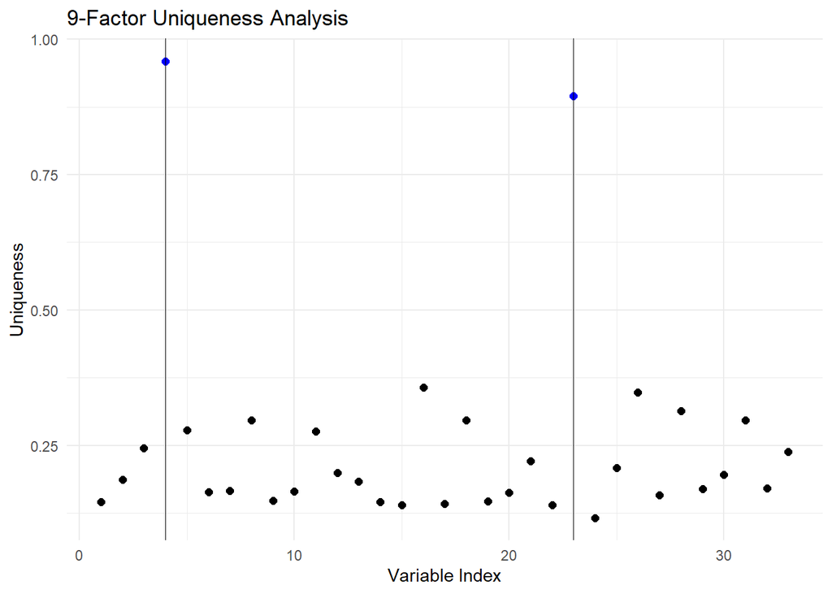

```r
FA9_Unq <- factanal(phone_133_all, factors = 9, rotation = 'varimax')

# Create a data frame with the diagonal values and their indices
df <- data.frame(values = FA9_Unq$uniquenesses, index = 1:33)

# Plot the diagonal values using ggplot2
ggplot(df, aes(x = index, y = values)) +
  geom_point(size = 2, color = ifelse(df$values > 0.8, "blue", "black")) +
  geom_vline(xintercept = 4,lwd = .05,color = "black") +
  geom_vline(xintercept = 23,lwd = .05,color = "black") +
  scale_x_continuous(name = "Variable Index") +
  scale_y_continuous(name = "Uniqueness") +
  ggtitle("9-Factor Uniqueness Analysis") +
  theme_minimal()
```

In factor analysis, it is important to understand to what extent each variable relates to the underlying constructs represented by the factors. When these unique values are high, it suggests that the variable may not be well equipped by the proposed factors. In both scenarios, $qd4$ and $qd23$ are much higher than all the other questions. This means they are less relevant and should continue to be on the watch list.

Next, we will run the different combinations of factors, and removed ‘watch list’ variables to analyze how the loadings compare to the relative factors.

```r
FA8_all <- fa(phone_133_all, nfactors = 8, rotate = "varimax", fm = "pa")
FA8_423 <- fa(phone_133_all[, -c(4, 23)], nfactors = 8, rotate = "varimax", fm = "pa")
FA9_all <- fa(phone_133_all, nfactors = 9, rotate = "varimax", fm = "pa")
FA9_423 <- fa(phone_133_all[, -c(4, 23)], nfactors = 9, rotate = "varimax", fm = "pa")
```

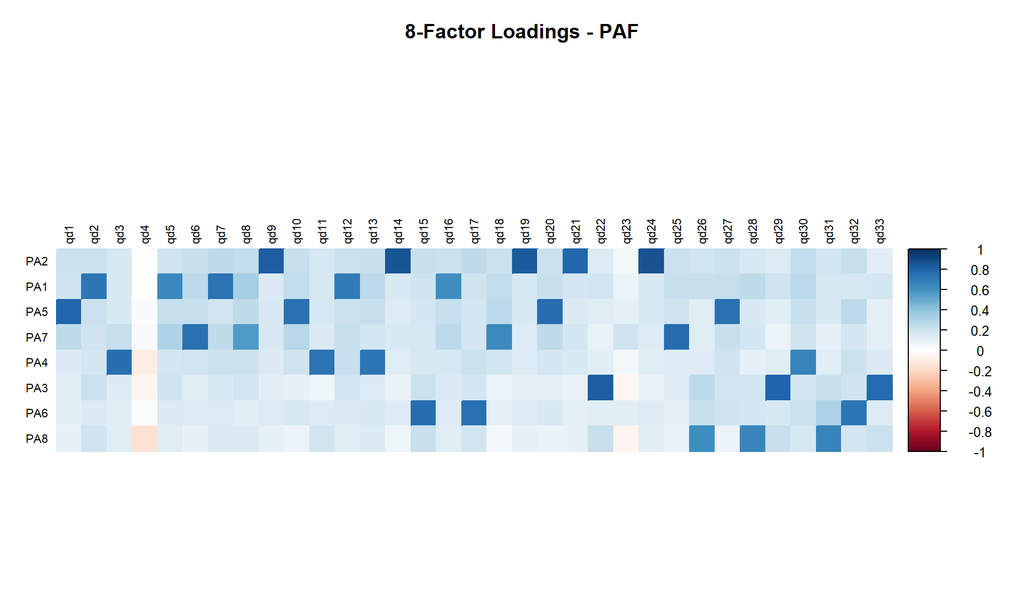

```r
corrplot(t(FA8_all$loadings),
         tl.cex = 0.7,
         tl.col = "black",
         number.cex = 0.8,
         method = 'color',
         title = "8-Factor Loadings - PAF",
         mar = c(0, 1, 3, 0))
```

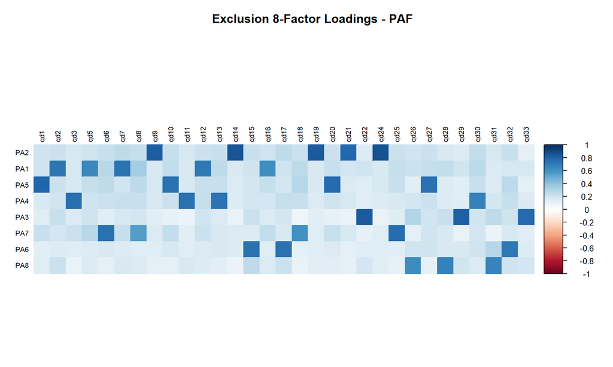

```r
corrplot(t(FA8_423$loadings),
         tl.cex = 0.7,
         tl.col = "black",
         number.cex = 0.8,
         method = 'color',
         title = "Exclusion 8-Factor Loadings - PAF",
         mar = c(0, 1, 3, 0))
```

We ran PAF with 8-factors again, but without those two variables on the watch list. This time, all variables are within a specific factor and clearly have a high loading as all of the blue dots are darker, signifying that there is a strong relationship.

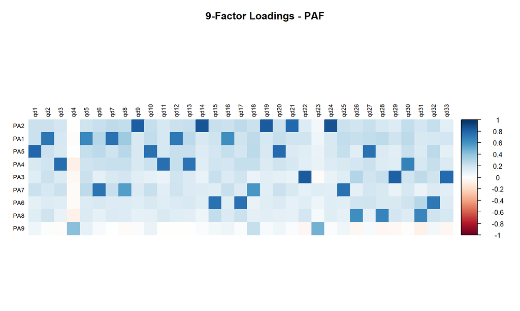

```r
corrplot(t(FA9_all$loadings),
         tl.cex = 0.7,
         tl.col = "black",
         number.cex = 0.8,
         method = 'color',
         title = "9-Factor Loadings - PAF",
         mar = c(0, 1, 3, 0))
```

Although PAF with 9-factors did not the lowest $BIC$ or $rms$, it did slightly have a better $fit$. Therefore, we analyzed the relationships between all the questions and the respective factors. This time, the two variables are within their own factor but seem to be less correlated then the other items within their dimension.

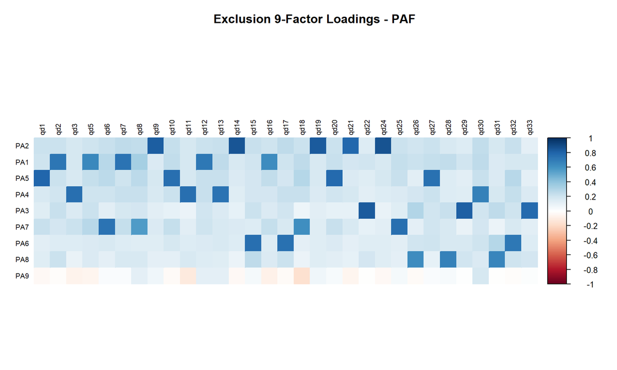

```r
corrplot(t(FA9_423$loadings),
         tl.cex = 0.7,
         tl.col = "black",
         number.cex = 0.8,
         method = 'color',
         title = "Exclusion 9-Factor Loadings - PAF",
         mar = c(0, 1, 3, 0))
```

The same exercise was repeated again, $qd4$ and $qd23$ were removed. If the 9-factors are reviewed, there are no items within that dimension. Therefore, this model would not be acceptable.

The loadings are an important estimation when it comes to analyzing the correlation between each observed variable and the proposed factors. They can be thought of as weights. When the weight is higher, that indicates the question is associated with the factor. Therefore, we should only possibly consider two of the models, FA8_423 and FA9_all. The other two have issues with the loading weights are too low or no questions in a certain factor. even though we could argue that the Exclusion 8-factors Loadings - PAF is the better choice due to model measurements, we will continue to go through each analysis with both for further comparison to ensure the best model is chosen.

```r
print(FA8_423$loadings, cutoff = 0.4, sort = TRUE)
```

```
##
## Loadings:
##      PA2   PA1   PA5   PA4   PA3   PA7   PA6   PA8
## qd9  0.827
## qd14 0.851
## qd19 0.832
## qd21 0.785
## qd24 0.860
## qd2        0.723
## qd5        0.645
## qd7        0.738
## qd12       0.711
## qd16       0.616
## qd1              0.797
## qd10             0.749
## qd20             0.772
## qd27             0.747
## qd3                    0.759
## qd11                   0.749
## qd13                   0.739
## qd30                   0.677
## qd22                         0.837
## qd29                         0.813
## qd33                         0.780
## qd6                                0.741
## qd8                                0.558
## qd18                               0.601
## qd25                               0.762
## qd15                                     0.749
## qd17                                     0.744
## qd32                                     0.715
## qd26                                           0.620
## qd28                                           0.672
## qd31                                           0.660
##
##                  PA2   PA1   PA5   PA4   PA3   PA7   PA6   PA8
## SS loadings    4.569 3.577 3.404 3.121 2.781 2.675 2.324 1.935
## Proportion Var 0.147 0.115 0.110 0.101 0.090 0.086 0.075 0.062
## Cumulative Var 0.147 0.263 0.373 0.473 0.563 0.649 0.724 0.787
```

```r
print(FA9_all$loadings, cutoff = 0.4, sort = TRUE)
```

```
##
## Loadings:
##      PA2    PA1    PA5    PA4    PA3    PA7    PA6    PA8    PA9
## qd9   0.830
## qd14  0.853
## qd19  0.834
## qd21  0.788
## qd24  0.862
## qd2          0.727
## qd5          0.649
## qd7          0.743
## qd12         0.716
## qd16         0.619
## qd1                 0.796
## qd10                0.747
## qd20                0.772
## qd27                0.748
## qd3                        0.761
## qd11                       0.750
## qd13                       0.736
## qd30                       0.674
## qd22                              0.835
## qd29                              0.813
## qd33                              0.779
## qd6                                      0.735
## qd8                                      0.559
## qd18                                     0.589
## qd25                                     0.746
## qd15                                            0.749
## qd17                                            0.743
## qd32                                            0.712
## qd26                                                   0.616
## qd28                                                   0.661
## qd31                                                   0.653
## qd4                                                           0.414
## qd23                                                          0.474
##
##                  PA2   PA1   PA5   PA4   PA3   PA7   PA6   PA8   PA9
## SS loadings    4.632 3.667 3.412 3.134 2.783 2.559 2.320 1.882 0.517
## Proportion Var 0.140 0.111 0.103 0.095 0.084 0.078 0.070 0.057 0.016
## Cumulative Var 0.140 0.251 0.355 0.450 0.534 0.612 0.682 0.739 0.755
```

The factors displayed above are a relatively good representation of what is displayed within the correlation matrix. At a threshold of 0.4, all questions appear to be appropriately grouped within a specific dimension. The main difference between the two loadings is that PA9’s items are low compared to all others (0.414 and 0.474). These may not be good to keep within the model. Additionally, the cumulative variation is slightly higher in the 8-factor at 78.7% compared to 75.5%.

```r
sort(FA8_423$communality)
```

```
##      qd18      qd16      qd26      qd28       qd8      qd31      qd11       qd5
## 0.6266777 0.6402010 0.6551763 0.6849299 0.6855023 0.7001560 0.7169741 0.7224583
##      qd33       qd3      qd21      qd30      qd12      qd25       qd2      qd13
## 0.7612886 0.7629531 0.7706646 0.7756551 0.7829168 0.8004648 0.8052923 0.8058405
##      qd32      qd29      qd10       qd7      qd20      qd27       qd6       qd9
## 0.8295319 0.8312862 0.8333518 0.8357790 0.8360730 0.8390860 0.8392665 0.8406325
##      qd19      qd14       qd1      qd15      qd22      qd17      qd24
## 0.8435205 0.8526145 0.8538126 0.8560076 0.8572538 0.8573949 0.8826324
```

As stated earlier, principal axis factoring focuses on covariances. The communality is the shared variance which is shown above. There appears to be no variables that would potentially be considered on the watch list since we consider that the ‘gaps’ are not larger enough to eliminate any variable. We run this analysis again but on 9-factors. There a reader will notice that $qd4$ and $qd23$ are extremely low compared to the third highest item at 0.64. Therefore, we would suggest sticking with the Exclusion 8-factors Loadings - PAF model.

```r
sort(FA9_all$communality)
```

```
##       qd4      qd23      qd16      qd26      qd18      qd28       qd8      qd31
## 0.1860315 0.2740969 0.6409344 0.6570266 0.6693727 0.6805048 0.6954544 0.7034429
##      qd11       qd5      qd33       qd3      qd21      qd30      qd12      qd25
## 0.7194675 0.7286179 0.7617402 0.7666282 0.7707646 0.7740474 0.7848395 0.7916454
##      qd13       qd2      qd32      qd29      qd10      qd20       qd7      qd27
## 0.8026750 0.8047862 0.8286370 0.8325405 0.8333801 0.8365920 0.8368335 0.8404022
##       qd9       qd6      qd19      qd14       qd1      qd22      qd17      qd15
## 0.8405512 0.8421117 0.8439347 0.8525442 0.8531018 0.8557809 0.8564535 0.8588101
##      qd24
## 0.8825049
```

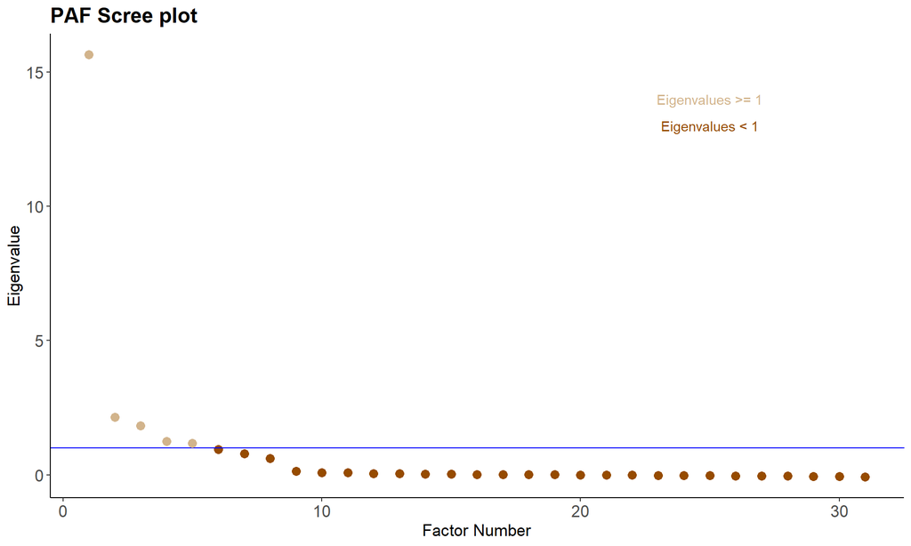

```r
# Create a data frame of eigenvalues and factor numbers
eigenvalues <- data.frame(factor_number = 1:length(FA8_423$values), eigenvalue = FA8_423$values)

# Create a logical vector indicating which eigenvalues are greater than 1
greater_than_1 <- FA8_423$values > 1

# Create the plot using ggplot()
ggplot(eigenvalues, aes(x = 1:length(FA8_423$values), y = FA8_423$values)) +
  geom_point(size = 3, color = "#964B00") +
  geom_abline(intercept = 1, slope = 0, color = "blue") +
  geom_point(data = eigenvalues[greater_than_1, ], aes(x = factor_number, y = eigenvalue), size = 3, color = "#D2B48C") +
  labs(x = "Factor Number", y = "Eigenvalue", title = "PAF Scree plot") +
  theme_bw() +
  theme(plot.title = element_text(size = rel(1.5), face = "bold"),
        axis.title = element_text(size = rel(1.2)),
        axis.text = element_text(size = rel(1.2)),
        axis.line = element_line(size = 0.5),
        panel.grid.major = element_blank(),
        panel.grid.minor = element_blank(),
        panel.border = element_blank()) +
  annotate("text", x = 25, y = 13, label = "Eigenvalues < 1", colour="#964B00") + annotate("text", x = 25, y = 14, label = "Eigenvalues >= 1", colour="#D2B48C") + theme(plot.title = element_text(face="bold"))
```

The graph above shows a screeplot, which is a ‘graphical representation of eigenvalues by ordering them according to their size’. The rule is subjective because the analyst is supposed to retain the eigenvalues above the break or elbow of the curve. This is very difficult to visualize. If we had to guess, it would most likely be 4-factors or 8-factors. Therefore, a more concrete approach is to look at the Kaiser criterion. The main rule to follow is that only eigenvalues greater than 1 should be extracted. If that eigenvalue is less than 1, this means that the factor ‘contributes less than a single variable in explaining total variance’. It is seen within the screeplot that there is an 5-factor solution by the two-toned points indicating which eigenvalues are above that threshold.

## 2.4 Final Factor Solution

To obtain the final model, there were various steps that needed to occur in order to figure out how many factors and which questions were to be kept moving forward. There were several prominent findings that aided our decision.

1. From the beginning, $qd4$ and $qd23$ had a weak relationship with the other survey questions. Specific to these questions, they stood out because they referred to prestige and distinctiveness, but there were no additional predictors that fell within those categories. Additionally, how they were treated in the correlation matrix as separate entities showed that they should not be grouped together under one factor and the analyses to follow showed that.
2. Once acknowledging the watch list, the PAF helped conclude the number of factors that would produce the best model. There is a trade-off between better fit due to added complexity and losing some fit to obtain a more parsimonious model which is the end goal for PAF. Therefore, the 8-factor solution seemed to perform better with the lowest $BIC$. The reader show be cautious about this decision as there are multiple ways to choose how many factors should be represented in the model.
3. The unique values for questions 4 and 23 were extremely high compared to all others. This was a red flag.
4. The choice to remove questions 4 and 23 and to use only 8-factors was solidified by reviewing the communalities. Those questions clearly did not belong as the third lowest value was 0.40 above $qd23$’s value.

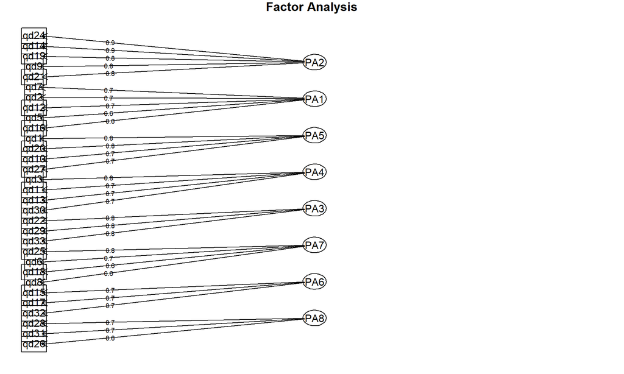

```r
fa.diagram(FA8_423)
```

Overall, the best fit model was FA8_423 due to these reasons. Additionally, they show clear loadings for the eight dimensions. A presentation of the loadings are in the diagram above. The eight factors can then be described through various dimensions outlined in the PDF provided in class. Before revealing those eight groups, it should be noted that we have agreed that ‘Conformance’ does not fit with the three questions that fall under PA6. Therefore, we recommend that the dimension and description changes to a factor that relates to ‘material.’

Below highlights the eight dimensions that could be matched to the 8-factor solution.

### 2.4.1 Serviceability

Involves the consumer’s ease of obtaining repair service (access to service centers and/or ease of self service), the responsiveness of service personnel and the reliability of the performed service  
- *Resource*: Brucks, Zeithaml, Naylor (2000)

The speed, courtesy, competence and ease of repair – the elapsed time before service is restored, the timelines  
- *Resource*: Garvin David A. (1988), Managing Quality, The free press, New York

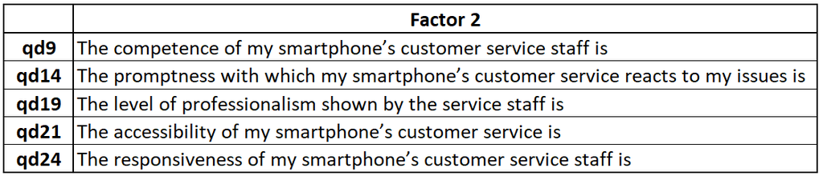

### 2.4.2 Performance

How well the product does what it is supposed to do – might well be multidimensional itself – e.g for cars power, comfort, safety – must perform well and must do so consistently. This consistency can be referred reliability or dependability  
- *Resource*: Brucks, Zeithaml, Naylor (2000)

Primary operating characteristics of a product e.g. for an automobile acceleration, handling, cruising speed and comfort  
- *Resource*: Garvin David A. (1988), Managing Quality, The free press, New York

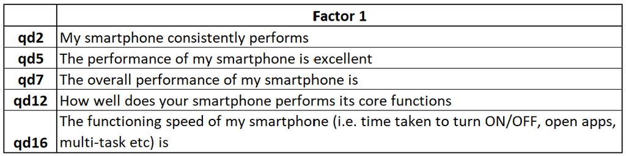

### 2.4.3 Material (New Dimension)

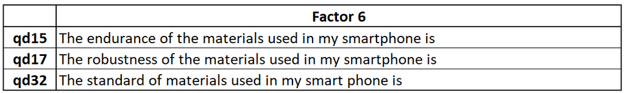

### 2.4.4 Durability

Involves the length of time the product lasts, the length of time the product works properly (i.e whether the product needs frequent servicing), how well the product holds up under adverse conditions such as weather heavy use or misuse  
- *Resource*: Brucks, Zeithaml, Naylor (2000)

A measure of product life – the amount of use one gets from a product before it breaks down and replacement is regarded as preferable to continued repair (has technical and economic dimensions)  
- *Resource*: Garvin David A. (1988), Managing Quality, The free press, New York

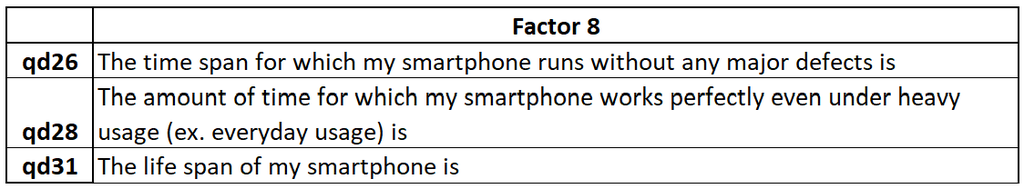

### 2.4.5 Aesthetics/Appearance

How a product looks, feels, sounds, tastes or smells – clearly a matter of personal judgments and a reflection of individual preferences – very subjective  
- *Resource*: Garvin David A. (1988), Managing Quality, The free press, New York

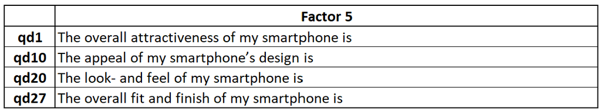

### 2.4.6 Ease of Use

Involves the consumer’s ability to start and operate the product as well as clarity of instrumentation and instructions – focus groups considered ease of use as an important dimension of quality  
- *Resource*: Brucks, Zeithaml, Naylor (2000)

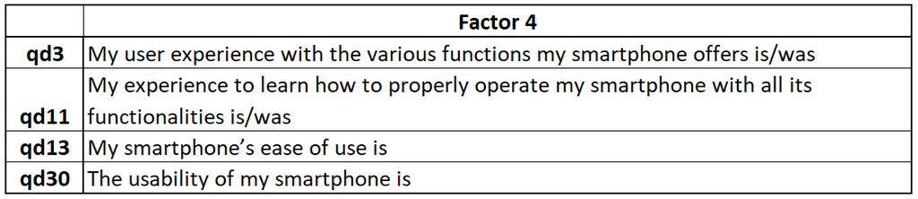

### 2.4.7 Features/Versatility

The number and complexity of the characteristics that distinguish the model or brand from a stripped-down model. The bells and whistles generally enable the product to perform more functions  
- *Resource*: Brucks, Zeithaml, Naylor (2000)

The bells and whistles of a products, those secondary characteristics that supplement the basic functioning of the product  
- *Resource*: Garvin David A. (1988), Managing Quality, The free press, New York

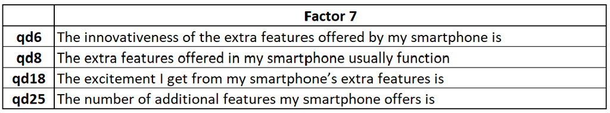

### 2.4.8 Reliability/Flawlessness

Reflects the probability of a product’s malfunctioning or failing within a specified period of time – can be measured with mean time to first failure (MTBF)  
- *Resource*: Garvin David A. (1988), Managing Quality, The free press, New York

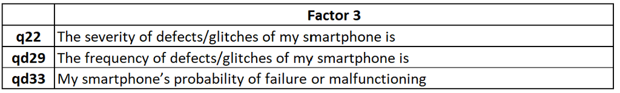

## 2.5 Principal Component Analysis (PCA)

The second factor extraction method is PCA. The goal here is to produce an empirical summary of a data set by reducing the dimensionality to capture relationships between variables and analyze patterns. Since the exercise states to run a PCA on the final solution from the PAF results, we will include eight factors and not include questions 4 and 23, as well as explore other options.

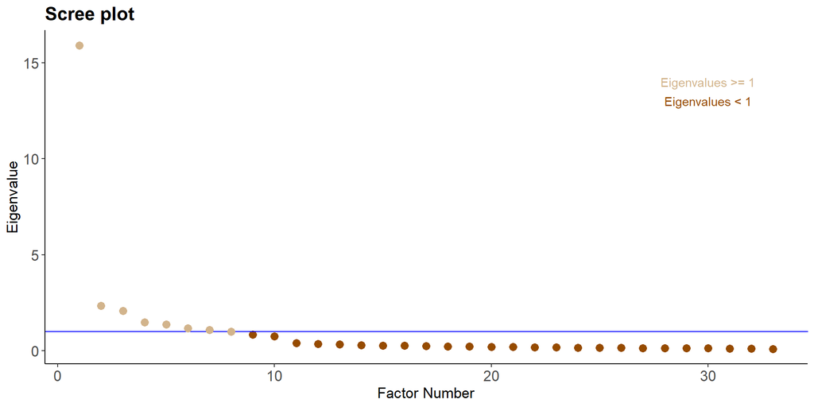

```r
plot_PCA <- psych::principal(phone_133_all, rotate = "varimax", nfactors = 33, scores = TRUE)

# Create a data frame of eigenvalues and factor numbers
eigenvalues <- data.frame(factor_number = 1:33, eigenvalue = plot_PCA$values)

# Create a logical vector indicating which eigenvalues are greater than 1
greater_than_1 <- plot_PCA$values > 1

# Create the plot using ggplot()
ggplot(eigenvalues, aes(x = factor_number, y = eigenvalue)) +
  geom_point(size = 3, color = "#964B00") +
  geom_abline(intercept = 1, slope = 0, color = "blue") +
  geom_point(data = eigenvalues[greater_than_1, ], aes(x = factor_number, y = eigenvalue), size = 3, color = "#D2B48C") +
  labs(x = "Factor Number", y = "Eigenvalue", title = "Scree plot") +
  theme_bw() +
  theme(plot.title = element_text(size = rel(1.5), face = "bold"),
        axis.title = element_text(size = rel(1.2)),
        axis.text = element_text(size = rel(1.2)),
        axis.line = element_line(size = 0.5),
        panel.grid.major = element_blank(),
        panel.grid.minor = element_blank(),
        panel.border = element_blank()) +
  annotate("text", x = 30, y = 13, label = "Eigenvalues < 1", colour="#964B00") + annotate("text", x = 30, y = 14, label = "Eigenvalues >= 1", colour="#D2B48C") + theme(plot.title = element_text(face="bold"))
```

Since there are many criterion to decide on the number of factor extraction, we start by looking at the eigenvalues. In PAF, there were only 5-factors above 1, and now there appear to be 8-factors when we start from stratch. This is not the only measure to review though. Once again, we will explore $rms$, and $fit$ to find the optimal model.

Since we have 8-factors listed above, we will look at factors 6 through 10, with and without questions 4 and 23.

```r
PCA6_423 <- principal(phone_133_all[, -c(4, 23)], nfactors = 6, rotate = "varimax", scores = TRUE)
summary(PCA6_423)
```

```
##
## Factor analysis with Call: principal(r = phone_133_all[, -c(4, 23)], nfactors = 6, rotate = "varimax",
##     scores = TRUE)
##
## Test of the hypothesis that 6 factors are sufficient.
## The degrees of freedom for the model is 294  and the objective function was  3.38
## The number of observations was  969  with Chi Square =  3217.27  with prob <  0
##
## The root mean square of the residuals (RMSA) is  0.04
```

```r
PCA7_423 <- principal(phone_133_all[, -c(4, 23)], nfactors = 7, rotate = "varimax", scores = TRUE)
summary(PCA7_423)
```

```
##
## Factor analysis with Call: principal(r = phone_133_all[, -c(4, 23)], nfactors = 7, rotate = "varimax",
##     scores = TRUE)
##
## Test of the hypothesis that 7 factors are sufficient.
## The degrees of freedom for the model is 269  and the objective function was  2.29
## The number of observations was  969  with Chi Square =  2183.85  with prob <  1.6e-296
##
## The root mean square of the residuals (RMSA) is  0.03
```

```r
PCA8_423 <- principal(phone_133_all[, -c(4, 23)], nfactors = 8, rotate = "varimax", scores = TRUE)
summary(PCA8_423)
```

```
##
## Factor analysis with Call: principal(r = phone_133_all[, -c(4, 23)], nfactors = 8, rotate = "varimax",
##     scores = TRUE)
##
## Test of the hypothesis that 8 factors are sufficient.
## The degrees of freedom for the model is 245  and the objective function was  1.82
## The number of observations was  969  with Chi Square =  1729.66  with prob <  2.3e-221
##
## The root mean square of the residuals (RMSA) is  0.02
```

```r
PCA9_423 <- principal(phone_133_all[, -c(4, 23)], nfactors = 9, rotate = "varimax", scores = TRUE)
summary(PCA9_423)
```

```
##
## Factor analysis with Call: principal(r = phone_133_all[, -c(4, 23)], nfactors = 9, rotate = "varimax",
##     scores = TRUE)
##
## Test of the hypothesis that 9 factors are sufficient.
## The degrees of freedom for the model is 222  and the objective function was  2.15
## The number of observations was  969  with Chi Square =  2040.63  with prob <  4.9e-291
##
## The root mean square of the residuals (RMSA) is  0.02
```

```r
PCA10_423 <- principal(phone_133_all[, -c(4, 23)], nfactors = 10, rotate = "varimax", scores = TRUE)
summary(PCA10_423)
```

```
##
## Factor analysis with Call: principal(r = phone_133_all[, -c(4, 23)], nfactors = 10, rotate = "varimax",
##     scores = TRUE)
##
## Test of the hypothesis that 10 factors are sufficient.
## The degrees of freedom for the model is 200  and the objective function was  2.58
## The number of observations was  969  with Chi Square =  2449.5  with prob <  0
##
## The root mean square of the residuals (RMSA) is  0.02
```

```r
PCA6_all <- principal(phone_133_all, nfactors = 6, rotate = "varimax", scores = TRUE)
summary(PCA6_all)
```

```
##
## Factor analysis with Call: principal(r = phone_133_all, nfactors = 6, rotate = "varimax",
##     scores = TRUE)
##
## Test of the hypothesis that 6 factors are sufficient.
## The degrees of freedom for the model is 345  and the objective function was  3.94
## The number of observations was  969  with Chi Square =  3750.13  with prob <  0
##
## The root mean square of the residuals (RMSA) is  0.04
```

```r
PCA7_all <- principal(phone_133_all, nfactors = 7, rotate = "varimax", scores = TRUE)
summary(PCA7_all)
```

```
##
## Factor analysis with Call: principal(r = phone_133_all, nfactors = 7, rotate = "varimax",
##     scores = TRUE)
##
## Test of the hypothesis that 7 factors are sufficient.
## The degrees of freedom for the model is 318  and the objective function was  3.5
## The number of observations was  969  with Chi Square =  3330.12  with prob <  0
##
## The root mean square of the residuals (RMSA) is  0.04
```

```r
PCA8_all <- principal(phone_133_all, nfactors = 8, rotate = "varimax", scores = TRUE)
summary(PCA8_all)
```

```
##
## Factor analysis with Call: principal(r = phone_133_all, nfactors = 8, rotate = "varimax",
##     scores = TRUE)
##
## Test of the hypothesis that 8 factors are sufficient.
## The degrees of freedom for the model is 292  and the objective function was  2.64
## The number of observations was  969  with Chi Square =  2511.99  with prob <  0
##
## The root mean square of the residuals (RMSA) is  0.03
```

```r
PCA9_all <- principal(phone_133_all, nfactors = 9, rotate = "varimax", scores = TRUE)
summary(PCA9_all)
```

```
##
## Factor analysis with Call: principal(r = phone_133_all, nfactors = 9, rotate = "varimax",
##     scores = TRUE)
##
## Test of the hypothesis that 9 factors are sufficient.
## The degrees of freedom for the model is 267  and the objective function was  2.24
## The number of observations was  969  with Chi Square =  2129.5  with prob <  4.4e-287
##
## The root mean square of the residuals (RMSA) is  0.03
```

```r
PCA10_all <- principal(phone_133_all, nfactors = 10, rotate = "varimax", scores = TRUE)
summary(PCA10_all)
```

```
##
## Factor analysis with Call: principal(r = phone_133_all, nfactors = 10, rotate = "varimax",
##     scores = TRUE)
##
## Test of the hypothesis that 10 factors are sufficient.
## The degrees of freedom for the model is 243  and the objective function was  1.86
## The number of observations was  969  with Chi Square =  1766.65  with prob <  3.8e-229
##
## The root mean square of the residuals (RMSA) is  0.02
```

```r
# Create a data frame with two columns
my_table <- data.frame(
  Model = c("6-factor_423", "7-factor_423", "8-factor_423", "9-factor_423", "10-factor_423", "6-factor_all", "7-factor_all", "8-factor_all", "9-factor_all", "10-factor_all"),
  rms = c(0.03656, 0.02755, 0.01961, 0.01924, 0.01883, 0.04244, 0.03727, 0.03034, 0.02501,0.01839),
  fit = c(0.9889, 0.9927, 0.9955, 0.9961, 0.9966,  0.9827,  0.9871,  0.9908,  0.9935,  0.9956))

# Print the table
print(my_table)
```

```
##            Model     rms    fit
## 1   6-factor_423 0.03656 0.9889
## 2   7-factor_423 0.02755 0.9927
## 3   8-factor_423 0.01961 0.9955
## 4   9-factor_423 0.01924 0.9961
## 5  10-factor_423 0.01883 0.9966
## 6   6-factor_all 0.04244 0.9827
## 7   7-factor_all 0.03727 0.9871
## 8   8-factor_all 0.03034 0.9908
## 9   9-factor_all 0.02501 0.9935
## 10 10-factor_all 0.01839 0.9956
```

```r
sort(PCA10_all$communality)
```

```
##      qd16      qd18       qd8      qd26       qd5      qd31      qd28      qd30
## 0.7283694 0.7516579 0.7530489 0.7708933 0.7800535 0.7916076 0.8055633 0.8154692
##      qd11      qd12      qd21       qd3       qd2      qd13       qd7      qd25
## 0.8173072 0.8235556 0.8254960 0.8325685 0.8363938 0.8418185 0.8548721 0.8549029
##      qd33       qd6       qd9      qd10      qd19      qd27      qd29      qd20
## 0.8571892 0.8608017 0.8717715 0.8735724 0.8741658 0.8785617 0.8801344 0.8802786
##      qd14      qd32       qd1      qd22      qd24      qd17      qd15      qd23
## 0.8810422 0.8879448 0.8910183 0.8921397 0.8982019 0.9010692 0.9017948 0.9911283
##       qd4
## 0.9965632
```

```r
sort(PCA8_423$communality)
```

```
##      qd16      qd18       qd8      qd26       qd5      qd31      qd28      qd30
## 0.7281547 0.7417442 0.7445806 0.7696596 0.7781026 0.7916366 0.8042188 0.8142034
##      qd11      qd12      qd21       qd3       qd2      qd13      qd25       qd7
## 0.8172090 0.8230745 0.8252227 0.8320578 0.8362610 0.8401490 0.8514445 0.8541838
##      qd33       qd6       qd9      qd10      qd19      qd27      qd20      qd29
## 0.8570641 0.8581700 0.8717486 0.8732182 0.8739140 0.8771753 0.8792219 0.8799137
##      qd14      qd32       qd1      qd22      qd24      qd17      qd15
## 0.8809326 0.8882966 0.8907906 0.8911649 0.8980463 0.9009975 0.9012585
```

All of the communalities seem to reflect a higher values than in principal axis analysis as even the lowest are above 0.70. As a reminder, the watch list predictors were not included since we are comparing to the final model. Additionally, it can be noticed that within PCA10_all, those two watch list questions have extremely high communalities.

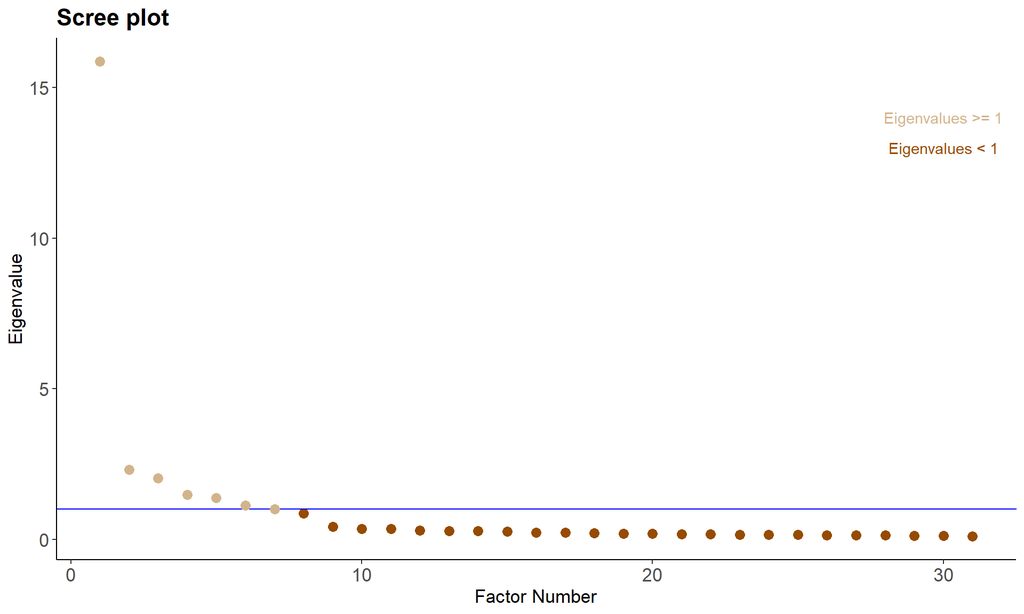

```r
plot_PCA8_423 <- psych::principal(phone_133_all[, -c(4, 23)], rotate = "varimax", nfactors = 8, scores = TRUE)

# Create a data frame of eigenvalues and factor numbers
eigenvalues <- data.frame(factor_number = 1:31, eigenvalue = plot_PCA8_423$values)

# Create a logical vector indicating which eigenvalues are greater than 1
greater_than_1 <- plot_PCA8_423$values > 1

# Create the plot using ggplot()
ggplot(eigenvalues, aes(x = factor_number, y = eigenvalue)) +
  geom_point(size = 3, color = "#964B00") +
  geom_abline(intercept = 1, slope = 0, color = "blue") +
  geom_point(data = eigenvalues[greater_than_1, ], aes(x = factor_number, y = eigenvalue), size = 3, color = "#D2B48C") +
  labs(x = "Factor Number", y = "Eigenvalue", title = "Scree plot") +
  theme_bw() +
  theme(plot.title = element_text(size = rel(1.5), face = "bold"),
        axis.title = element_text(size = rel(1.2)),
        axis.text = element_text(size = rel(1.2)),
        axis.line = element_line(size = 0.5),
        panel.grid.major = element_blank(),
        panel.grid.minor = element_blank(),
        panel.border = element_blank()) +
  annotate("text", x = 30, y = 13, label = "Eigenvalues < 1", colour="#964B00") + annotate("text", x = 30, y = 14, label = "Eigenvalues >= 1", colour="#D2B48C") + theme(plot.title = element_text(face="bold"))
```

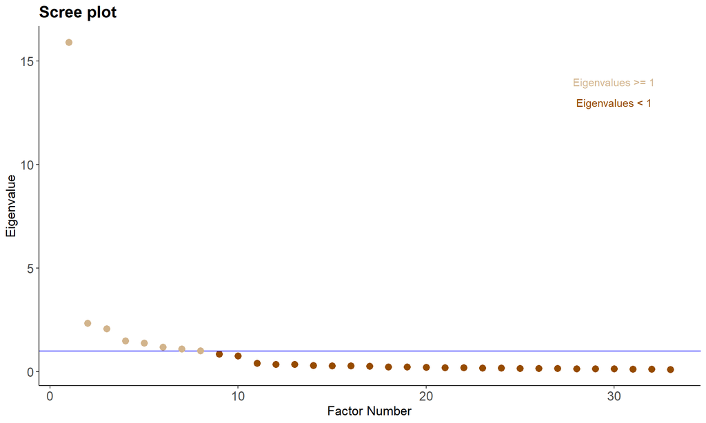

```r
plot_PCA10_all <- psych::principal(phone_133_all, rotate = "varimax", nfactors = 10, scores = TRUE)

# Create a data frame of eigenvalues and factor numbers
eigenvalues <- data.frame(factor_number = 1:33, eigenvalue = plot_PCA10_all$values)

# Create a logical vector indicating which eigenvalues are greater than 1
greater_than_1 <- plot_PCA10_all$values > 1

# Create the plot using ggplot()
ggplot(eigenvalues, aes(x = factor_number, y = eigenvalue)) +
  geom_point(size = 3, color = "#964B00") +
  geom_abline(intercept = 1, slope = 0, color = "blue") +
  geom_point(data = eigenvalues[greater_than_1, ], aes(x = factor_number, y = eigenvalue), size = 3, color = "#D2B48C") +
  labs(x = "Factor Number", y = "Eigenvalue", title = "Scree plot") +
  theme_bw() +
  theme(plot.title = element_text(size = rel(1.5), face = "bold"),
        axis.title = element_text(size = rel(1.2)),
        axis.text = element_text(size = rel(1.2)),
        axis.line = element_line(size = 0.5),
        panel.grid.major = element_blank(),
        panel.grid.minor = element_blank(),
        panel.border = element_blank()) +
  annotate("text", x = 30, y = 13, label = "Eigenvalues < 1", colour="#964B00") + annotate("text", x = 30, y = 14, label = "Eigenvalues >= 1", colour="#D2B48C") + theme(plot.title = element_text(face="bold"))
```

After running both scree plots for those two models, PCA8_423 shows a 7-factor solution while PCA10_all shows eight dimensions. To check the total variance explained for both, we run the eigenvalues and respective variance distributed to each factor.

## 2.6 Total Variance Explained

```r
EigenValue = PCA8_423$values

Variance = EigenValue/ncol(subset(phone_133_all, select = c(qd1:qd31)))*100

SumVariance = cumsum(EigenValue/ncol(subset(phone_133_all, select = c(qd1:qd31))))

Total_Variance_Explained = cbind(EigenValue = EigenValue[EigenValue > 0], Variance = Variance[EigenValue > 0], Total_Variance = SumVariance[EigenValue > 0])

Total_Variance_Explained
```

```
##       EigenValue   Variance Total_Variance
##  [1,] 15.8598680 51.1608646      0.5116086
##  [2,]  2.3217762  7.4896008      0.5865047
##  [3,]  2.0258331  6.5349453      0.6518541
##  [4,]  1.4781631  4.7682680      0.6995368
##  [5,]  1.3712708  4.4234540      0.7437713
##  [6,]  1.1343846  3.6593051      0.7803644
##  [7,]  1.0135713  3.2695850      0.8130602
##  [8,]  0.8689483  2.8030591      0.8410908
##  [9,]  0.4176516  1.3472632      0.8545635
## [10,]  0.3618149  1.1671450      0.8662349
## [11,]  0.3511069  1.1326029      0.8775609
## [12,]  0.2984164  0.9626335      0.8871873
## [13,]  0.2897893  0.9348042      0.8965353
## [14,]  0.2773548  0.8946931      0.9054822
```

[output cut: 17 more lines]

The first eigenvalue is 15.86, which means that it can explain 51.2% of the overall variance. As the eigenvalues continue to decrease to just above the threshold, we obtain a total variance of 84.1% with 8-factors.

```r
EigenValue = PCA10_all$values

Variance = EigenValue/ncol(subset(phone_133_all, select = c(qd1:qd33)))*100

SumVariance = cumsum(EigenValue/ncol(subset(phone_133_all, select = c(qd1:qd33))))

Total_Variance_Explained = cbind(EigenValue = EigenValue[EigenValue > 0], Variance = Variance[EigenValue > 0], Total_Variance = SumVariance[EigenValue > 0])

Total_Variance_Explained
```

```
##       EigenValue   Variance Total_Variance
##  [1,] 15.9082244 48.2067407      0.4820674
##  [2,]  2.3398002  7.0903037      0.5529704
##  [3,]  2.0741379  6.2852665      0.6158231
##  [4,]  1.4922324  4.5219164      0.6610423
##  [5,]  1.3853335  4.1979804      0.7030221
##  [6,]  1.1868699  3.5965755      0.7389878
##  [7,]  1.0936900  3.3142121      0.7721300
##  [8,]  1.0096776  3.0596291      0.8027262
##  [9,]  0.8530507  2.5850023      0.8285763
## [10,]  0.7579386  2.2967837      0.8515441
## [11,]  0.4066927  1.2324022      0.8638681
## [12,]  0.3605823  1.0926736      0.8747949
## [13,]  0.3509690  1.0635424      0.8854303
## [14,]  0.2970630  0.9001911      0.8944322
```

[output cut: 19 more lines]

The first eigenvalue is 15.91, which means that it can explain 48.2% of the overall variance. As the eigenvalues continue to decrease to just above the threshold, we obtain a total variance of 85.2% with 10-factors.

Last but not least, we recheck the loadings for each model.

```r
print(PCA8_423$loadings, cutoff = 0.4, sort = TRUE)
```

```
##
## Loadings:
##      RC2   RC1   RC5   RC4   RC7   RC6   RC3   RC8
## qd9  0.847
## qd14 0.868
## qd19 0.851
## qd21 0.823
## qd24 0.869
## qd2        0.754
## qd5        0.704
## qd7        0.758
## qd12       0.750
## qd16       0.708
## qd1              0.822
## qd10             0.778
## qd20             0.803
## qd27             0.774
## qd3                    0.807
## qd11                   0.819
## qd13                   0.763
## qd30                   0.706
## qd6                          0.762
## qd8                          0.626
## qd18                         0.715
## qd25                         0.806
## qd22                               0.854
## qd29                               0.841
## qd33                               0.842
## qd15                                     0.787
## qd17                                     0.780
## qd32                                     0.765
## qd26                                           0.727
## qd28                                           0.773
## qd31                                           0.738
##
##                  RC2   RC1   RC5   RC4   RC7   RC6   RC3   RC8
## SS loadings    4.673 3.908 3.492 3.297 3.020 2.856 2.492 2.337
## Proportion Var 0.151 0.126 0.113 0.106 0.097 0.092 0.080 0.075
## Cumulative Var 0.151 0.277 0.389 0.496 0.593 0.685 0.766 0.841
```

```r
print(PCA10_all$loadings, cutoff = 0.4, sort = TRUE)
```

```
##
## Loadings:
##      RC2    RC1    RC6    RC4    RC8    RC3    RC5    RC9    RC10   RC7
## qd9   0.849
## qd14  0.869
## qd19  0.852
## qd21  0.824
## qd24  0.870
## qd2          0.757
## qd5          0.706
## qd7          0.761
## qd12         0.753
## qd16         0.710
## qd1                 0.822
## qd10                0.778
## qd20                0.803
## qd27                0.775
## qd3                        0.805
## qd11                       0.818
## qd13                       0.764
## qd30                       0.707
## qd6                               0.759
## qd8                               0.628
## qd18                              0.698
## qd25                              0.805
## qd22                                     0.854
## qd29                                     0.841
## qd33                                     0.842
## qd15                                            0.785
## qd17                                            0.779
## qd32                                            0.763
## qd26                                                   0.725
## qd28                                                   0.772
## qd31                                                   0.735
## qd23                                                          0.972
## qd4                                                                  0.989
##
##                  RC2   RC1   RC6   RC4   RC8   RC3   RC5   RC9  RC10   RC7
## SS loadings    4.714 3.960 3.502 3.300 2.958 2.851 2.476 2.313 1.017 1.011
## Proportion Var 0.143 0.120 0.106 0.100 0.090 0.086 0.075 0.070 0.031 0.031
## Cumulative Var 0.143 0.263 0.369 0.469 0.559 0.645 0.720 0.790 0.821 0.852
```

It is clear that there are distinct loadings shown within the rotated matrices. In addition, both explain over 80% of the total variance. What is seen now though is that RC10 and RC7 are broken out by themselves. These correlate to questions 4 and 23. This is troubling because even though there is a distinctiveness/prestige dimension, there would need to be additional questions in order to include these if that was a possibility. Therefore, the final model once again with be 8-factors, excluding those variables.

Based on the final solution for PAF and what was obtained through PCA, the results ended up being the same at the end but not concretely throughout the analysis. For example, PAF wanted to group those two questions into one factor while PCA wanted them to be independent of each other due to their low correlations to any other predictors. Since we knew that we had two watch list values, we built additional models to ensure that we captured everything so nothing fell through the cracks.

Throughout this analysis, the main objective has been to understand the importance of perceived quality in building a competitive advantage in the smartphone industry. Several studies support the claim that changes in quality perceptions have been positively correlated with the firm’s profitability and successful corporate performance. However, there is not a standard product quality scale that exists today. To combat this problem, a major smartphone producer kick started a project to measure product quality of smartphones in terms of its constituent dimensions. More importantly though, product management’s goal is to obtain a deeper understanding about which quality dimensions significantly impact key outcome variables such as willingness to pay premium and repurchase intentions.

Out of the nine quality dimensions defined, we found that eight factors explained the relevance of a customer’s repurchase behavior. These are mentioned above with their respective definitions. This is important because the eigenvalues show the contribution of a specific factor in measuring the total variance. With this 8-factor solution, it contributed 84.1% of the total variation. Having a high eigenvalue means that more weight should be given in a subsequent analysis, like *Problem 2* and that those factors will possibly provide more information than the others when it comes to wanting to focus on the most important dimensions.

# 3 Problem 2: Oblique Factor Analysis

Run an oblique factor analysis with the variables of your final solution in exercise 1 using Promax. How high are the factors correlated and what is the highest correlation between factors. What does this mean – please explain. Compute factor scores for your factors and name and label them appropriately. Compute mean scores for the three willingness to pay premium items ($wtp1$ - $wtp3$) and the two repurchase intention items ($ri1$ -$ri2$). Run a regression analysis with the factor scores of the quality dimensions as independent and both the mean score of willingness to pay premium and repurchase intention as dependent variables. Interpret your results from a managerial perspective. Do the results of the regression analysis for repurchase intentions differ across brands e.g. Samsung versus Apple versus LG. What do the results of these regressions imply? Please compare the brands on the factor scores. What are points of parity and points of difference for the different brands. Develop a report of your key results.

## 3.1 Oblique Factor Analysis

Compute factor scores for your factors and name and label them appropriately. Run a regression analysis with the factor scores of the quality dimensions as independent and both the mean score of willingness to pay premium and repurchase intention as dependent variables

Run an oblique factor analysis with the variables of your final solution in *Exercise 1* using Promax.

Based on the Promax factor analysis conducted, the loadings are shown for eight rotated components, with each variable assigned to the component where it has the highest loading. The loadings table shows the relationship between the different survey questions and each factor. It appears that all items have loadings above 0.60.

Overall, these findings indicate that the quality dimensions can be classified into eight factors that are correlated with one another and account for a significant amount of variance in the data. These variables (factors) can be used to gain a better understanding of the relationship between quality perceptions and key outcome variables like willingness to pay a premium (WTP) and repurchase intentions (RI).

```r
phone_all_qd <- phone_all[,c(1:33)] #qd data
phone_all_wtp_ri <- phone_all[,c(34:38)] #wtp and ri data

phone_all_qd <- phone_all_qd[,-c(4,23)]

# Run Promax factor analysis on the data without qd4 and qd22
promax_fa <- psych::fa(phone_all_qd, rotate = "promax", nfactors = 8, scores = TRUE)

# Print the factor loadings
print(promax_fa$loadings, cutoff = 0.3, sort = TRUE)
```

```
##
## Loadings:
##      MR2    MR1    MR5    MR4    MR7    MR6    MR3    MR8
## qd9   0.904
## qd14  0.945
## qd19  0.912
## qd21  0.851
## qd24  0.951
## qd2          0.919
## qd5          0.767
## qd7          0.937
## qd12         0.900
## qd16         0.746
## qd1                 0.966
## qd10                0.865
## qd20                0.914
## qd27                0.867
## qd3                        0.910
## qd11                       0.908
## qd13                       0.850
## qd30                       0.740
## qd6                               0.909
## qd8                               0.600
## qd18                              0.699
## qd25                              0.976
## qd15                                     0.917
## qd17                                     0.912
## qd32                                     0.862
## qd22                                            0.940
## qd29                                            0.899
## qd33                                            0.866
## qd26                                                   0.729
## qd28                                                   0.833
## qd31                                                   0.785
##
##                  MR2   MR1   MR5   MR4   MR7   MR6   MR3   MR8
## SS loadings    4.177 3.738 3.303 2.943 2.669 2.453 2.477 1.870
## Proportion Var 0.135 0.121 0.107 0.095 0.086 0.079 0.080 0.060
## Cumulative Var 0.135 0.255 0.362 0.457 0.543 0.622 0.702 0.762
```

The communality corresponds to the percentage of variance in a variable explained by factors because the questions are standardized to account for the possibility of different scales. If the communality of any of the questions is less than 0.5, we would consider removing those values because they would not accurately represent the factors in the model. The variables with a high communality are likely to be important for understanding the underlying dimensions of the data and should be included in further analysis. The lowest communality is 0.63, so there are no variables on the watch list because the gaps are below the threshold.

```r
sort(promax_fa$communality)
```

```
##      qd18      qd16      qd26       qd8      qd28      qd31      qd11       qd5
## 0.6264756 0.6401977 0.6543623 0.6854270 0.6864510 0.6998168 0.7170257 0.7224507
##      qd33       qd3      qd21      qd30      qd12      qd25       qd2      qd13
## 0.7606924 0.7631400 0.7706616 0.7755797 0.7829022 0.8014884 0.8052686 0.8057144
##      qd32      qd29      qd10       qd7      qd20       qd6      qd27       qd9
## 0.8293067 0.8309835 0.8333236 0.8358204 0.8360452 0.8388622 0.8390417 0.8406222
##      qd19      qd14       qd1      qd15      qd17      qd22      qd24
## 0.8435127 0.8526219 0.8539385 0.8561542 0.8575192 0.8583147 0.8826484
```

```r
promax_fa1 <- psych::fa(phone_all_wtp_ri, rotate = "promax", nfactors = 2, scores = TRUE)
# Print the factor loadings
print(promax_fa1$loadings, cutoff = 0.3, sort = TRUE)
```

```
##
## Loadings:
##      MR1    MR2
## wtp1  0.842
## wtp2  0.533  0.328
## wtp3  0.991
## ri1          0.974
## ri2          0.847
##
##                  MR1   MR2
## SS loadings    1.979 1.777
## Proportion Var 0.396 0.355
## Cumulative Var 0.396 0.751
```

The factor scores printed below are based on the variables that load most strongly on. A high positive score might indicate a high level of customer satisfaction with smartphone performance, while a negative score might indicate low satisfaction.

```r
#convert scores to dataframe
pred_df <- data.frame(promax_fa$scores)
pred_df <- cbind(pred_df,promax_fa1$scores)

#rename columns
colnames(pred_df)[1:10] = c("Serviceability",
                          "Performance",
                          "Aesthetics",
                          "Ease_of_Use",
                          "Features",
                          "Material",
                          "Reliability",
                          "Durability",
                          "Willingness_to_Pay",
                          "Repurchase_Intention")
#print table
pred_df
```

```
##      Serviceability   Performance  Aesthetics  Ease_of_Use     Features
## 1      -1.094168450 -5.864534e-01 -1.42193277 -0.708820737 -0.936341849
## 2       0.140794640 -1.952982e-01 -0.10223225 -0.621851532  0.256685938
## 3      -1.094006264 -5.430677e-01 -1.41273741 -0.832119600 -0.821459841
## 4       0.338200106  1.081643e+00  1.21991546  0.983393557  1.336617175
## 5      -1.062609087 -4.880610e-01 -0.15565408  0.503510899 -0.920822980
## 6      -1.096701850 -4.895208e-01 -1.45512459 -1.369265521 -0.923924723
## 7       0.146526395  8.542517e-01  0.14457656  0.545642579 -0.671867437
## 8      -0.471847796 -1.339763e+00 -0.50801698 -0.325209404 -0.773635930
## 9      -1.053123955 -5.998689e-02 -1.00377836  1.107113623 -0.625059069
## 10      1.337958592  8.258389e-01 -0.11831070 -0.894569011 -1.151938747
## 11     -0.646320943 -1.765347e+00 -0.52305542 -1.424957115 -1.223200701
## 12      0.078994637 -7.947309e-01 -0.83593621 -0.416493258 -0.810982624
## 13     -1.171629288 -1.007110e+00 -1.42899746 -1.651963379 -1.131186141
## 14     -0.807491639 -8.348721e-02 -0.10631390 -0.015806386 -0.286474842
```

[output cut: 2895 more lines]

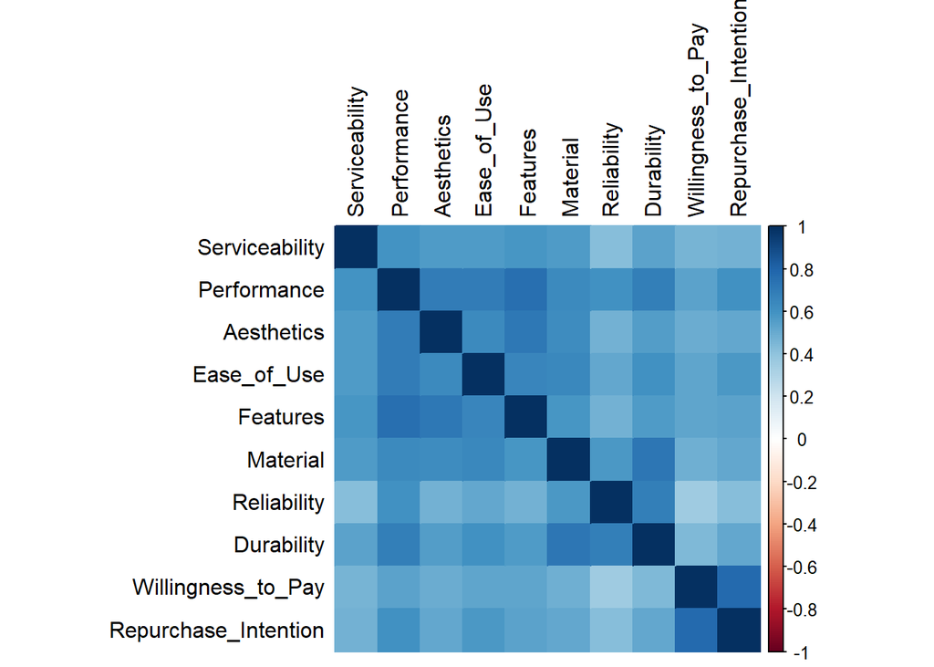

```r
pred_corr_matrix <- cor(pred_df)
corrplot(as.matrix(pred_corr_matrix, numbers), tl.col = "black", number.cex = 0.8, method = 'color')
```

```r
#merge factor scores with all the data
pred_df <- as.data.table(pred_df)
factor_scores_all <- cbind(phone_all, pred_df)
factor_scores_all
```

```
##      qd1 qd2 qd3 qd4 qd5 qd6 qd7 qd8 qd9 qd10 qd11 qd12 qd13 qd14 qd15 qd16
## 1      3   4   3   3   4   3   4   3   3    3    3    3    4    3    3    4
## 2      4   4   3   6   4   4   4   4   4    4    3    4    4    4    4    4
## 3      3   4   3   2   3   3   3   4   3    3    4    5    3    3    3    4
## 4      5   5   4   3   5   5   5   5   4    5    5    5    5    4    4    4
## 5      4   4   5   2   3   3   4   4   3    4    5    4    4    3    4    3
## 6      3   4   3   5   3   3   4   3   3    3    3    4    3    3    4    4
## 7      4   5   5   2   5   3   5   3   4    5    4    5    4    4    4    4
## 8      3   3   4   2   3   3   3   4   4    4    3    4    4    4    3    2
## 9      4   4   5   2   4   3   4   4   3    3    5    4    5    3    4    5
## 10     4   5   3   5   4   3   5   3   5    4    3    5    3    5    4    5
## 11     4   2   2   2   2   3   3   2   4    4    3    4    3    3    3    3
## 12     3   4   4   5   4   3   3   3   4    4    4    4    4    4    3    3
## 13     3   4   2   5   3   3   3   4   4    3    3    4    3    2    4    3
## 14     4   4   4   4   3   4   4   4   3    4    4    5    4    3    5    4
```

[output cut: 4835 more lines]

## 3.2 Regressions of WTP and RI

The first two regression analyses use different models to predict Willingness to Pay (WTP). The first model has eight factors and two additional variables, $qd23$ and $qd4$. The second model only employs eight factors.

In both models, the variables Serviceability, Performance, Ease_of_Use, and Features have positive coefficients and are statistically significant. This indicates that, regardless of the model used, these variables have a positive effect on WTP.

The adjusted R-squared values for both models are relatively low, indicating that there may be other factors influencing WTP that are not captured by the model.

The adjusted R-squared value for the RI model is also relatively low, implying that there may be other factors influencing RI that the model does not account for.

Overall, the model with 8 factors and no additional variables appears to be a good fit for both WTP and RI based on the coefficients and statistical significance.

```r
#run regression WTP with 8 factors, qd23, and qd4
wtp_model <- lm(Willingness_to_Pay ~ Serviceability + Performance + Aesthetics + Ease_of_Use + Features + Material + Reliability + Durability + qd4 + qd23, data = factor_scores_all)

summary(wtp_model, standardise = TRUE)
```

```
##
## Call:
## lm(formula = Willingness_to_Pay ~ Serviceability + Performance +
##     Aesthetics + Ease_of_Use + Features + Material + Reliability +
##     Durability + qd4 + qd23, data = factor_scores_all)
##
## Residuals:
##      Min       1Q   Median       3Q      Max
## -2.81498 -0.47875  0.04784  0.54911  1.87498
##
## Coefficients:
##                Estimate Std. Error t value Pr(>|t|)
## (Intercept)    -0.42058    0.08204  -5.127 3.57e-07 ***
## Serviceability  0.10805    0.03365   3.211  0.00137 **
## Performance     0.11592    0.04720   2.456  0.01423 *
## Aesthetics      0.06418    0.04002   1.604  0.10909
## Ease_of_Use     0.18462    0.03929   4.699 3.00e-06 ***
## Features        0.11281    0.04353   2.591  0.00970 **
## Material        0.07918    0.04118   1.923  0.05478 .
## Reliability    -0.02244    0.03607  -0.622  0.53411
## Durability      0.04078    0.04523   0.902  0.36740
## qd4             0.02059    0.01677   1.228  0.21980
## qd23            0.09344    0.01655   5.647 2.15e-08 ***
## ---
## Signif. codes:  0 '***' 0.001 '**' 0.01 '*' 0.05 '.' 0.1 ' ' 1
##
## Residual standard error: 0.7577 on 958 degrees of freedom
## Multiple R-squared:  0.3922, Adjusted R-squared:  0.3858
## F-statistic: 61.81 on 10 and 958 DF,  p-value: < 2.2e-16
```

```r
#run regression WTP with 8 factors
wtp_model1 <- lm(Willingness_to_Pay ~ Serviceability + Performance + Aesthetics + Ease_of_Use + Features + Material + Reliability + Durability, data = factor_scores_all)

summary(wtp_model1, standardise = TRUE)
```

```
##
## Call:
## lm(formula = Willingness_to_Pay ~ Serviceability + Performance +
##     Aesthetics + Ease_of_Use + Features + Material + Reliability +
##     Durability, data = factor_scores_all)
##
## Residuals:
##      Min       1Q   Median       3Q      Max
## -2.90700 -0.47084  0.07975  0.59520  1.89098
##
## Coefficients:
##                  Estimate Std. Error t value Pr(>|t|)
## (Intercept)    -1.473e-16  2.479e-02   0.000  1.00000
## Serviceability  1.072e-01  3.426e-02   3.129  0.00181 **
## Performance     1.223e-01  4.805e-02   2.545  0.01107 *
## Aesthetics      7.715e-02  4.068e-02   1.896  0.05820 .
## Ease_of_Use     1.823e-01  3.986e-02   4.573 5.42e-06 ***
## Features        1.388e-01  4.410e-02   3.148  0.00169 **
## Material        9.842e-02  4.180e-02   2.354  0.01876 *
## Reliability    -3.999e-02  3.661e-02  -1.092  0.27503
## Durability      2.646e-02  4.586e-02   0.577  0.56405
## ---
## Signif. codes:  0 '***' 0.001 '**' 0.01 '*' 0.05 '.' 0.1 ' ' 1
##
## Residual standard error: 0.7715 on 960 degrees of freedom
## Multiple R-squared:  0.3685, Adjusted R-squared:  0.3632
## F-statistic: 70.01 on 8 and 960 DF,  p-value: < 2.2e-16
```

```r
#run regression RI with 8 factors, qd23, and qd4
ri_model <- lm(Repurchase_Intention ~ Serviceability + Performance + Aesthetics + Ease_of_Use + Features + Material + Reliability + Durability + qd4 + qd23, data = factor_scores_all)

summary(ri_model, standardise = TRUE)
```

```
##
## Call:
## lm(formula = Repurchase_Intention ~ Serviceability + Performance +
##     Aesthetics + Ease_of_Use + Features + Material + Reliability +
##     Durability + qd4 + qd23, data = factor_scores_all)
##
## Residuals:
##     Min      1Q  Median      3Q     Max
## -2.7700 -0.4074  0.1244  0.4902  2.3246
##
## Coefficients:
##                Estimate Std. Error t value Pr(>|t|)
## (Intercept)    -0.35742    0.07852  -4.552 6.00e-06 ***
## Serviceability  0.08164    0.03221   2.535 0.011412 *
## Performance     0.22467    0.04518   4.973 7.80e-07 ***
## Aesthetics      0.04198    0.03830   1.096 0.273406
## Ease_of_Use     0.22392    0.03760   5.955 3.65e-09 ***
## Features        0.03373    0.04167   0.810 0.418363
## Material        0.03419    0.03941   0.868 0.385821
## Reliability     0.02482    0.03452   0.719 0.472384
## Durability      0.09530    0.04329   2.202 0.027932 *
## qd4             0.03631    0.01605   2.263 0.023879 *
## qd23            0.06050    0.01584   3.820 0.000142 ***
## ---
## Signif. codes:  0 '***' 0.001 '**' 0.01 '*' 0.05 '.' 0.1 ' ' 1
##
## Residual standard error: 0.7252 on 958 degrees of freedom
## Multiple R-squared:  0.444,  Adjusted R-squared:  0.4382
## F-statistic: 76.49 on 10 and 958 DF,  p-value: < 2.2e-16
```

```r
#run regression RI with 8 factors, qd23, and qd4
ri_model2 <- lm(Repurchase_Intention ~ Serviceability + Performance + Aesthetics + Ease_of_Use + Features + Material + Reliability + Durability + qd4 + qd23, data = factor_scores_all)

summary(ri_model2, standardise = TRUE)
```

```
##
## Call:
## lm(formula = Repurchase_Intention ~ Serviceability + Performance +
##     Aesthetics + Ease_of_Use + Features + Material + Reliability +
##     Durability + qd4 + qd23, data = factor_scores_all)
##
## Residuals:
##     Min      1Q  Median      3Q     Max
## -2.7700 -0.4074  0.1244  0.4902  2.3246
##
## Coefficients:
##                Estimate Std. Error t value Pr(>|t|)
## (Intercept)    -0.35742    0.07852  -4.552 6.00e-06 ***
## Serviceability  0.08164    0.03221   2.535 0.011412 *
## Performance     0.22467    0.04518   4.973 7.80e-07 ***
## Aesthetics      0.04198    0.03830   1.096 0.273406
## Ease_of_Use     0.22392    0.03760   5.955 3.65e-09 ***
## Features        0.03373    0.04167   0.810 0.418363
## Material        0.03419    0.03941   0.868 0.385821
## Reliability     0.02482    0.03452   0.719 0.472384
## Durability      0.09530    0.04329   2.202 0.027932 *
## qd4             0.03631    0.01605   2.263 0.023879 *
## qd23            0.06050    0.01584   3.820 0.000142 ***
## ---
## Signif. codes:  0 '***' 0.001 '**' 0.01 '*' 0.05 '.' 0.1 ' ' 1
##
## Residual standard error: 0.7252 on 958 degrees of freedom
## Multiple R-squared:  0.444,  Adjusted R-squared:  0.4382
## F-statistic: 76.49 on 10 and 958 DF,  p-value: < 2.2e-16
```

```r
#run regression RI with 8 factors
ri_model3 <- lm(ri1 ~ Serviceability + Performance + Aesthetics + Ease_of_Use + Features + Material + Reliability + Durability, data = factor_scores_all)

summary(ri_model3, standardise = TRUE)
```

```
##
## Call:
## lm(formula = ri1 ~ Serviceability + Performance + Aesthetics +
##     Ease_of_Use + Features + Material + Reliability + Durability,
##     data = factor_scores_all)
##
## Residuals:
##     Min      1Q  Median      3Q     Max
## -4.9925 -0.6741  0.2260  0.8083  3.5063
##
## Coefficients:
##                Estimate Std. Error t value Pr(>|t|)
## (Intercept)     5.29825    0.03822 138.641  < 2e-16 ***
## Serviceability  0.12138    0.05282   2.298   0.0218 *
## Performance     0.34378    0.07408   4.641 3.95e-06 ***
## Aesthetics      0.07617    0.06272   1.214   0.2249
## Ease_of_Use     0.32810    0.06146   5.339 1.17e-07 ***
## Features        0.04995    0.06800   0.735   0.4628
## Material        0.04674    0.06446   0.725   0.4685
## Reliability     0.01567    0.05645   0.278   0.7813
## Durability      0.12009    0.07072   1.698   0.0898 .
## ---
## Signif. codes:  0 '***' 0.001 '**' 0.01 '*' 0.05 '.' 0.1 ' ' 1
##
## Residual standard error: 1.19 on 960 degrees of freedom
## Multiple R-squared:  0.3684, Adjusted R-squared:  0.3631
## F-statistic: 69.98 on 8 and 960 DF,  p-value: < 2.2e-16
```

```r
#run regression RI with 8 factors
ri_model4 <- lm(ri2 ~ Serviceability + Performance + Aesthetics + Ease_of_Use + Features + Material + Reliability + Durability, data = factor_scores_all)

summary(ri_model4, standardise = TRUE)
```

```
##
## Call:
## lm(formula = ri2 ~ Serviceability + Performance + Aesthetics +
##     Ease_of_Use + Features + Material + Reliability + Durability,
##     data = factor_scores_all)
##
## Residuals:
##     Min      1Q  Median      3Q     Max
## -4.4360 -0.5890  0.1653  0.7280  3.3083
##
## Coefficients:
##                Estimate Std. Error t value Pr(>|t|)
## (Intercept)     5.38287    0.03529 152.538  < 2e-16 ***
## Serviceability  0.09385    0.04878   1.924   0.0546 .
## Performance     0.36573    0.06841   5.346 1.12e-07 ***
## Aesthetics      0.08574    0.05792   1.480   0.1391
## Ease_of_Use     0.28768    0.05675   5.069 4.80e-07 ***
## Features        0.07905    0.06279   1.259   0.2084
## Material        0.08212    0.05952   1.380   0.1680
## Reliability     0.03863    0.05213   0.741   0.4588
## Durability      0.12385    0.06530   1.897   0.0582 .
## ---
## Signif. codes:  0 '***' 0.001 '**' 0.01 '*' 0.05 '.' 0.1 ' ' 1
##
## Residual standard error: 1.098 on 960 degrees of freedom
## Multiple R-squared:  0.4274, Adjusted R-squared:  0.4226
## F-statistic: 89.56 on 8 and 960 DF,  p-value: < 2.2e-16
```

## 3.3 Mean Scores

Compute mean scores for the three willingness to pay premium items ($wtp1$-$wtp3$) and the two repurchase intention items ($ri1$-$ri2$).

Run a regression analysis with the factor scores of the quality dimensions as independent and both the mean score of willingness to pay premium and repurchase intention as dependent variables.

The regression analysis suggests that the quality dimensions have a significant impact on both willingness to pay premium and repurchase intention for phones. Among the quality dimensions, Ease_of_Use and Features have the most significant effect on willingness to pay premium and Ease_of_Use and Performance to repurchase intention. The other quality dimensions, such as Aesthetics, Material, Reliability, and Durability, also have some impact, but their effect is relatively weaker.

From an industrial perspective, these findings imply that phone manufacturers should focus on enhancing Ease_of_Use and Performance to increase both willingness to pay premium and repurchase intention among customers. Additionally, phone manufacturers could also consider improving other quality dimensions, such as Aesthetics, Features, Material, Reliability, and Durability, to further enhance customer satisfaction and loyalty. However, since the effect of these dimensions is relatively weaker, manufacturers should prioritize their efforts on Ease_of_Use and Performance. Overall, these findings could provide valuable insights for phone manufacturers to develop high-quality products that meet the needs and expectations of their customers.

```r
# Calculate row-wise mean scores for wtp and ri
phone_all$mean_wtp <- rowMeans(phone_all[, c("wtp1", "wtp2", "wtp3")], na.rm = TRUE)
phone_all$mean_ri <- rowMeans(phone_all[, c("ri1", "ri2")], na.rm = TRUE)

phone_all <- phone_all[,-c(4,23)]
phone_all
```

```
##      qd1 qd2 qd3 qd5 qd6 qd7 qd8 qd9 qd10 qd11 qd12 qd13 qd14 qd15 qd16 qd17
## 1      3   4   3   4   3   4   3   3    3    3    3    4    3    3    4    3
## 2      4   4   3   4   4   4   4   4    4    3    4    4    4    4    4    4
## 3      3   4   3   3   3   3   4   3    3    4    5    3    3    3    4    3
## 4      5   5   4   5   5   5   5   4    5    5    5    5    4    4    4    5
## 5      4   4   5   3   3   4   4   3    4    5    4    4    3    4    3    4
## 6      3   4   3   3   3   4   3   3    3    3    4    3    3    4    4    3
## 7      4   5   5   5   3   5   3   4    5    4    5    4    4    4    4    4
## 8      3   3   4   3   3   3   4   4    4    3    4    4    4    3    2    3
## 9      4   4   5   4   3   4   4   3    3    5    4    5    3    4    5    4
## 10     4   5   3   4   3   5   3   5    4    3    5    3    5    4    5    5
## 11     4   2   2   2   3   3   2   4    4    3    4    3    3    3    3    3
## 12     3   4   4   4   3   3   3   4    4    4    4    4    4    3    3    3
## 13     3   4   2   3   3   3   4   4    3    3    4    3    2    4    3    4
## 14     4   4   4   3   4   4   4   3    4    4    5    4    3    5    4    4
```

[output cut: 2895 more lines]

```r
# Extract mean_wtp and mean_ri columns from phone_all
extracted_cols <- phone_all[, c("mean_wtp", "mean_ri")]

# Combine extracted columns with pred_df
combined_df <- cbind(pred_df, extracted_cols)
combined_df
```

```
##      Serviceability Performance Aesthetics Ease_of_Use   Features    Material
##   1:     -1.0941684  -0.5864534 -1.4219328 -0.70882074 -0.9363418 -1.10884286
##   2:      0.1407946  -0.1952982 -0.1022323 -0.62185153  0.2566859  0.05176558
##   3:     -1.0940063  -0.5430677 -1.4127374 -0.83211960 -0.8214598 -1.11492417
##   4:      0.3382001   1.0816429  1.2199155  0.98339356  1.3366172  0.95843816
##   5:     -1.0626091  -0.4880610 -0.1556541  0.50351090 -0.9208230  0.09355343
##  ---
## 965:      0.9710957  -0.1991446 -2.3055417 -0.03464764  1.1947448 -0.26039086
## 966:     -1.1241118  -1.5707553 -1.4591023 -1.39844874 -0.9709006 -1.17710965
## 967:      1.3757921   1.0293769  0.5684584  0.02700832  1.4576213  0.10331643
## 968:      1.1929084   0.6910695 -0.7798487  0.58102712 -0.7654603 -1.00779392
## 969:      1.4122845   1.2175401  0.6036536  1.30550276  1.4883601  1.39686530
##       Reliability Durability Willingness_to_Pay Repurchase_Intention mean_wtp
##   1: -1.044637283 -0.2684988         0.25023371           0.40427808 4.666667
##   2: -1.043348326 -0.8400749        -0.24328153          -0.01983656 4.333333
```

[output cut: 21 more lines]

```r
#run regression of wtp_mean with factor scores
combined_df <- as.data.table(combined_df)

wtp_model <- lm(mean_wtp ~ Serviceability + Performance + Aesthetics + Ease_of_Use + Features + Material + Reliability + Durability, data = combined_df)

#standardize the data on regression only
summary(wtp_model, standardise = TRUE)
```

```
##
## Call:
## lm(formula = mean_wtp ~ Serviceability + Performance + Aesthetics +
##     Ease_of_Use + Features + Material + Reliability + Durability,
##     data = combined_df)
##
## Residuals:
##     Min      1Q  Median      3Q     Max
## -4.6259 -0.7192  0.1191  0.8381  2.8554
##
## Coefficients:
##                Estimate Std. Error t value Pr(>|t|)
## (Intercept)     4.57585    0.03685 124.180  < 2e-16 ***
## Serviceability  0.15337    0.05093   3.011  0.00267 **
## Performance     0.17590    0.07143   2.463  0.01397 *
## Aesthetics      0.08720    0.06048   1.442  0.14970
## Ease_of_Use     0.28339    0.05926   4.782 2.01e-06 ***
## Features        0.20341    0.06557   3.102  0.00198 **
## Material        0.16068    0.06215   2.585  0.00988 **
## Reliability    -0.02835    0.05443  -0.521  0.60255
## Durability      0.03384    0.06819   0.496  0.61978
## ---
## Signif. codes:  0 '***' 0.001 '**' 0.01 '*' 0.05 '.' 0.1 ' ' 1
##
## Residual standard error: 1.147 on 960 degrees of freedom
## Multiple R-squared:  0.3693, Adjusted R-squared:  0.364
## F-statistic: 70.26 on 8 and 960 DF,  p-value: < 2.2e-16
```

```r
#run regression of mean_ri with factor scores
ri_model <- lm(mean_ri ~ Serviceability + Performance + Aesthetics + Ease_of_Use + Features + Material + Reliability + Durability, data = combined_df)

#standardize the data on regression only
summary(ri_model, standardise = TRUE)
```

```
##
## Call:
## lm(formula = mean_ri ~ Serviceability + Performance + Aesthetics +
##     Ease_of_Use + Features + Material + Reliability + Durability,
##     data = combined_df)
##
## Residuals:
##     Min      1Q  Median      3Q     Max
## -4.3226 -0.6419  0.1804  0.7190  3.3105
##
## Coefficients:
##                Estimate Std. Error t value Pr(>|t|)
## (Intercept)     5.34056    0.03433 155.577  < 2e-16 ***
## Serviceability  0.10762    0.04745   2.268   0.0235 *
## Performance     0.35476    0.06654   5.331 1.22e-07 ***
## Aesthetics      0.08095    0.05634   1.437   0.1511
## Ease_of_Use     0.30789    0.05521   5.577 3.18e-08 ***
## Features        0.06450    0.06108   1.056   0.2913
## Material        0.06443    0.05790   1.113   0.2660
## Reliability     0.02715    0.05071   0.536   0.5924
## Durability      0.12197    0.06352   1.920   0.0551 .
## ---
## Signif. codes:  0 '***' 0.001 '**' 0.01 '*' 0.05 '.' 0.1 ' ' 1
##
## Residual standard error: 1.069 on 960 degrees of freedom
## Multiple R-squared:  0.4302, Adjusted R-squared:  0.4254
## F-statistic: 90.58 on 8 and 960 DF,  p-value: < 2.2e-16
```

## 3.4 Brand Analysis

Do the results of the regression analysis for repurchase intentions differ across brands e.g. Samsung versus Apple versus LG. What do the results of these regressions imply? Please compare the brands on the factor scores. What are points of parity and points of difference for the different brands.

In the outputs below we can see that the coefficients for each independent variable vary across brands.

The regression output for Apple shows that Serviceability, Aesthetics, and Ease_of_Use have significant positive coefficients at the 0.05 level, implying that these factors have a positive impact on customers’ willingness to pay for Apple phones. Performance, Features, Material, Reliability, and Durability, on the other hand, do not have significant coefficients at the 0.05 level, implying that these factors do not have a statistically significant impact on willingness to pay for Apple phones among customers who highly rated the brand.

Serviceability, Aesthetics, Ease_of_Use, Features, Material, and Durability do not appear to have a statistically significant relationship with mean_wtp in LG data, as their p-values are greater than the 0.05 significance level. When attempting to predict or explain variation in mean_wtp among respondents in brandrec3_df, it appears that reliability may be the most important factor to consider.

```r
# Keep only questions qd1 to qd33, willing to pay wtp1, wpt2, wtp3, repurchase intention ri1, and ri2 and brandrec
phone_all_1 <- phone[c(9:41,43:45,51:52,74)]

# Remove rows with missing data
phone_all_1 <- na.omit(phone_all_1) # 969 observations

#Combined database
combined_df_brands <- cbind(phone_all_1, combined_df)
combined_df_brands
```

```
##      qd1 qd2 qd3 qd4 qd5 qd6 qd7 qd8 qd9 qd10 qd11 qd12 qd13 qd14 qd15 qd16
## 1      3   4   3   3   4   3   4   3   3    3    3    3    4    3    3    4
## 2      4   4   3   6   4   4   4   4   4    4    3    4    4    4    4    4
## 3      3   4   3   2   3   3   3   4   3    3    4    5    3    3    3    4
## 4      5   5   4   3   5   5   5   5   4    5    5    5    5    4    4    4
## 5      4   4   5   2   3   3   4   4   3    4    5    4    4    3    4    3
## 6      3   4   3   5   3   3   4   3   3    3    3    4    3    3    4    4
## 7      4   5   5   2   5   3   5   3   4    5    4    5    4    4    4    4
## 8      3   3   4   2   3   3   3   4   4    4    3    4    4    4    3    2
## 9      4   4   5   2   4   3   4   4   3    3    5    4    5    3    4    5
## 10     4   5   3   5   4   3   5   3   5    4    3    5    3    5    4    5
## 11     4   2   2   2   2   3   3   2   4    4    3    4    3    3    3    3
## 12     3   4   4   5   4   3   3   3   4    4    4    4    4    4    3    3
## 13     3   4   2   5   3   3   3   4   4    3    3    4    3    2    4    3
## 14     4   4   4   4   3   4   4   4   3    4    4    5    4    3    5    4
```

[output cut: 4835 more lines]

```r
#APPLE regression
# subset the data frame to only include rows where brandrec == 1
brandrec1_df <- combined_df_brands[combined_df_brands$brandrec == 1, ]

# fit the linear regression model using the subsetted data frame
ri_model_apple <- lm(mean_wtp ~ Serviceability + Performance + Aesthetics + Ease_of_Use + Features + Material + Reliability + Durability, data = brandrec1_df)

# summarize the model results
summary(ri_model_apple)
```

```
##
## Call:
## lm(formula = mean_wtp ~ Serviceability + Performance + Aesthetics +
##     Ease_of_Use + Features + Material + Reliability + Durability,
##     data = brandrec1_df)
##
## Residuals:
##     Min      1Q  Median      3Q     Max
## -4.8267 -0.4842  0.1527  0.7518  2.2175
##
## Coefficients:
##                Estimate Std. Error t value Pr(>|t|)
## (Intercept)     4.90181    0.04617 106.166  < 2e-16 ***
## Serviceability  0.18279    0.06512   2.807  0.00519 **
## Performance     0.03011    0.09573   0.314  0.75328
## Aesthetics      0.21939    0.07620   2.879  0.00415 **
## Ease_of_Use     0.31203    0.07388   4.223 2.84e-05 ***
## Features        0.12181    0.07992   1.524  0.12808
## Material        0.14892    0.07794   1.911  0.05658 .
## Reliability    -0.06069    0.06652  -0.912  0.36199
## Durability      0.02394    0.08329   0.287  0.77390
## ---
## Signif. codes:  0 '***' 0.001 '**' 0.01 '*' 0.05 '.' 0.1 ' ' 1
##
## Residual standard error: 1.032 on 525 degrees of freedom
## Multiple R-squared:  0.3511, Adjusted R-squared:  0.3412
## F-statistic:  35.5 on 8 and 525 DF,  p-value: < 2.2e-16
```

```r
#SAMSUNG regression
# subset the data frame to only include rows where brandrec == 2
brandrec2_df <- combined_df_brands[combined_df_brands$brandrec == 2, ]

# fit the linear regression model using the subsetted data frame
ri_model_samsung <- lm(mean_wtp ~ Serviceability + Performance + Aesthetics + Ease_of_Use + Features + Material + Reliability + Durability, data = brandrec2_df)

# summarize the model results
summary(ri_model_samsung)
```

```
##
## Call:
## lm(formula = mean_wtp ~ Serviceability + Performance + Aesthetics +
##     Ease_of_Use + Features + Material + Reliability + Durability,
##     data = brandrec2_df)
##
## Residuals:
##     Min      1Q  Median      3Q     Max
## -3.5729 -0.6607  0.0838  0.7388  2.4382
##
## Coefficients:
##                Estimate Std. Error t value Pr(>|t|)
## (Intercept)     4.40256    0.07593  57.979   <2e-16 ***
## Serviceability  0.05582    0.10888   0.513   0.6087
## Performance     0.25345    0.13081   1.938   0.0539 .
## Aesthetics     -0.06149    0.12533  -0.491   0.6242
## Ease_of_Use     0.17788    0.12662   1.405   0.1614
## Features        0.21077    0.13324   1.582   0.1151
## Material        0.22678    0.12861   1.763   0.0792 .
## Reliability    -0.11350    0.11921  -0.952   0.3421
## Durability      0.08637    0.14664   0.589   0.5564
## ---
## Signif. codes:  0 '***' 0.001 '**' 0.01 '*' 0.05 '.' 0.1 ' ' 1
##
## Residual standard error: 1.133 on 225 degrees of freedom
## Multiple R-squared:  0.3189, Adjusted R-squared:  0.2946
## F-statistic: 13.17 on 8 and 225 DF,  p-value: 1.491e-15
```

```r
#LG data
# subset the data frame to only include rows where brandrec == 3
brandrec3_df <- combined_df_brands[combined_df_brands$brandrec == 3, ]

# fit the linear regression model using the subsetted data frame
ri_model_lg <- lm(mean_wtp ~ Serviceability + Performance + Aesthetics + Ease_of_Use + Features + Material + Reliability + Durability, data = brandrec3_df)

# summarize the model results
summary(ri_model_lg)
```

```
##
## Call:
## lm(formula = mean_wtp ~ Serviceability + Performance + Aesthetics +
##     Ease_of_Use + Features + Material + Reliability + Durability,
##     data = brandrec3_df)
##
## Residuals:
##     Min      1Q  Median      3Q     Max
## -2.7471 -0.9021 -0.1008  0.7988  2.8053
##
## Coefficients:
##                Estimate Std. Error t value Pr(>|t|)
## (Intercept)     3.85421    0.16588  23.235   <2e-16 ***
## Serviceability -0.21475    0.20405  -1.052   0.2973
## Performance    -0.27815    0.30605  -0.909   0.3675
## Aesthetics      0.02296    0.23847   0.096   0.9236
## Ease_of_Use     0.16183    0.22602   0.716   0.4771
## Features        0.35371    0.30788   1.149   0.2557
## Material        0.26885    0.24246   1.109   0.2724
## Reliability     0.39220    0.20434   1.919   0.0602 .
## Durability      0.25188    0.25151   1.001   0.3211
## ---
## Signif. codes:  0 '***' 0.001 '**' 0.01 '*' 0.05 '.' 0.1 ' ' 1
##
## Residual standard error: 1.219 on 54 degrees of freedom
## Multiple R-squared:  0.3525, Adjusted R-squared:  0.2566
## F-statistic: 3.674 on 8 and 54 DF,  p-value: 0.001743
```

## 3.5 Factor Score Comparison

Please compare the brands on the factor scores. What are points of parity and points of difference for the different brands.

According to the table, Apple(1) and Samsung(2) have relatively similar factor scores in Reliability (both positive), whereas LG has relatively lower factor scores across all attributes.

It is difficult to determine the point of parity from the table below. We can see that there are significant differences between brands in terms of points across the factor scores.

```r
brand_scores <- combined_df_brands |>
  group_by(brandrec) |>
  summarise(across(everything(), mean))
brand_scores <- brand_scores[-c(2:39)]
brand_scores
```

```
## # A tibble: 5 × 13
##   brandrec Serviceabil…¹ Perfo…² Aesth…³ Ease_…⁴ Featu…⁵ Mater…⁶ Relia…⁷ Durab…⁸
##      <int>         <dbl>   <dbl>   <dbl>   <dbl>   <dbl>   <dbl>   <dbl>   <dbl>
## 1        1        0.162    0.200  0.142   0.159   0.190    0.147  0.0939  0.124
## 2        2       -0.114   -0.115 -0.0588 -0.0962 -0.0842  -0.126  0.0249 -0.0933
## 3        3       -0.311   -0.298 -0.207  -0.216  -0.291   -0.189 -0.200  -0.134
## 4        4       -0.0962  -0.250 -0.225  -0.356  -0.385   -0.105 -0.219  -0.122
## 5        5       -0.482   -0.632 -0.478  -0.353  -0.532   -0.426 -0.407  -0.399
## # … with 4 more variables: Willingness_to_Pay <dbl>,
## #   Repurchase_Intention <dbl>, mean_wtp <dbl>, mean_ri <dbl>, and abbreviated
## #   variable names ¹Serviceability, ²Performance, ³Aesthetics, ⁴Ease_of_Use,
## #   ⁵Features, ⁶Material, ⁷Reliability, ⁸Durability
```

### 3.5.1 Resources

1: Investopedia, *What Is Platykurtic? Definition, Examples and Other*

2: https://www.statisticshowto.com/kaiser-meyer-olkin/

3: https://stats.stackexchange.com/questions/280746/what-is-the-difference-between-pca-and-paf-method-in-factor-analysis

4: https://cran.r-project.org/web/packages/corrplot/vignettes/corrplot-intro.html

5: https://stats.stackexchange.com/questions/266304/in-factor-analysis-or-in-pca-what-does-it-mean-a-factor-loading-greater-than#:~:text=However%2C%20if%20the%20factors%20are,larger%20than%20one%20in%20magnitude.%22